# Analyse des données des joueurs (expérimentations finales)

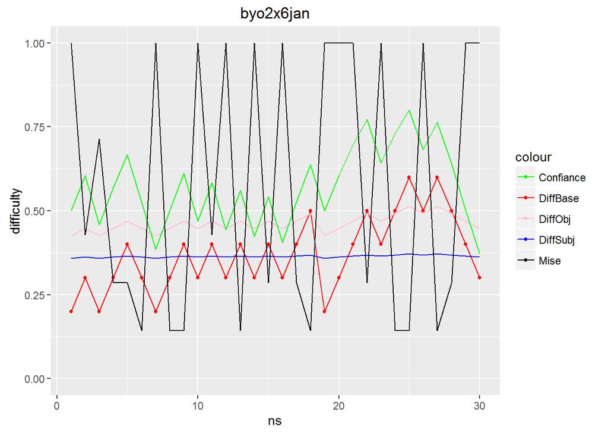

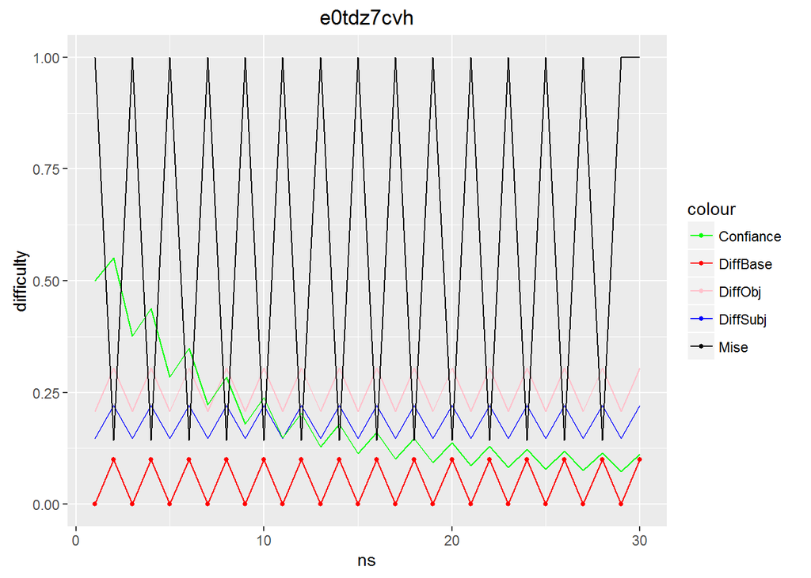

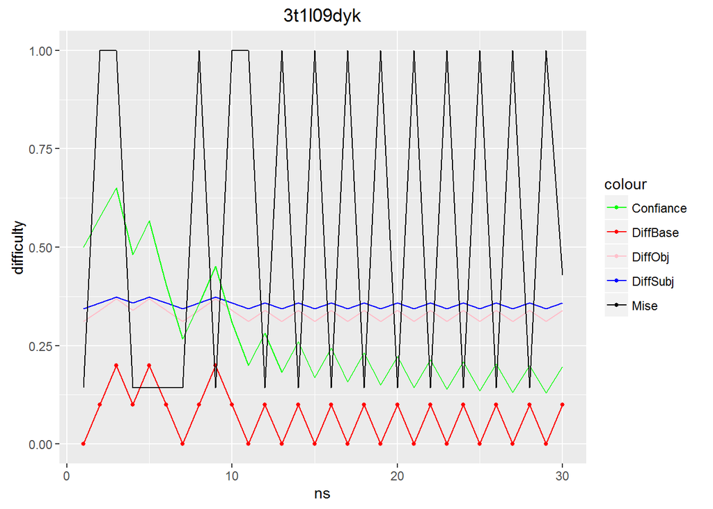

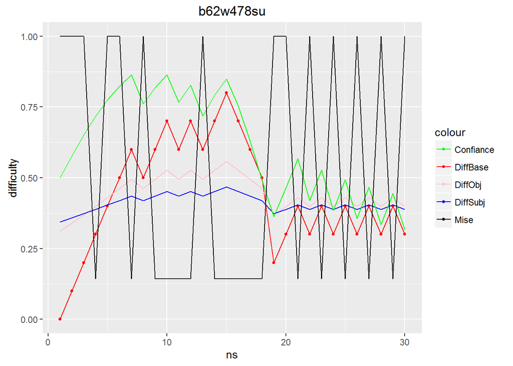

Il reste , **68** joueurs en moteur, **72** en logique et **72** joueurs en senso.

# Des essais…

```
## [1] "Logique"
```

```
## [1] 0
##
## Call:
## lm(formula = DTLoc$miseNorm ~ DTLoc$resLisse)
##
## Residuals:
##      Min       1Q   Median       3Q      Max
## -0.65604 -0.25684  0.02685  0.28829  0.44972
##
## Coefficients:
##                Estimate Std. Error t value Pr(>|t|)
## (Intercept)     0.51516    0.04705  10.950  < 2e-16 ***
## DTLoc$resLisse  0.69879    0.22051   3.169  0.00183 **
## ---
## Signif. codes:  0 '***' 0.001 '**' 0.01 '*' 0.05 '.' 0.1 ' ' 1
##
## Residual standard error: 0.315 on 160 degrees of freedom
## Multiple R-squared:  0.05906,    Adjusted R-squared:  0.05318
## F-statistic: 10.04 on 1 and 160 DF,  p-value: 0.001833
```

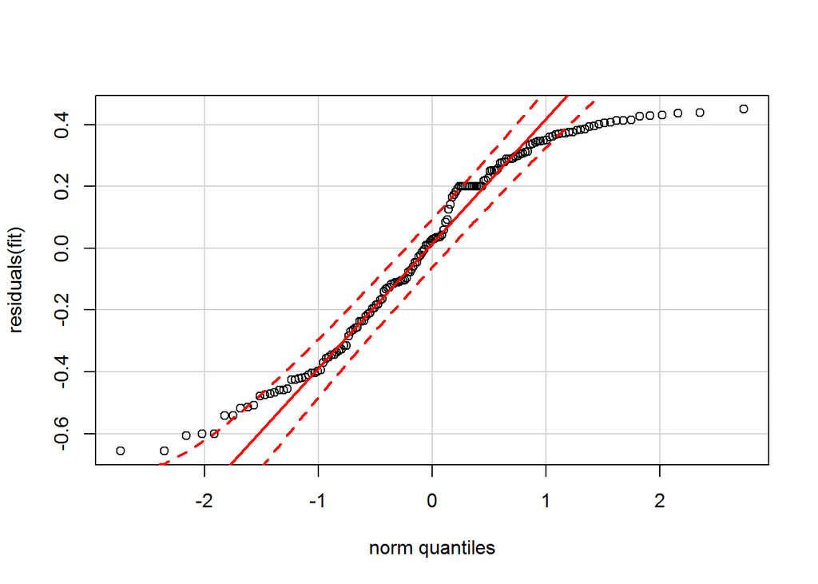

```
## NULL
## [1] "next"
## [1] 0.1
##
## Call:
## lm(formula = DTLoc$miseNorm ~ DTLoc$resLisse)
##
## Residuals:
##      Min       1Q   Median       3Q      Max
## -0.52146 -0.34733  0.05285  0.34929  0.36769
##
## Coefficients:
##                Estimate Std. Error t value Pr(>|t|)
## (Intercept)     0.66637    0.04522  14.736   <2e-16 ***
## DTLoc$resLisse -0.06921    0.14934  -0.463    0.643
## ---
## Signif. codes:  0 '***' 0.001 '**' 0.01 '*' 0.05 '.' 0.1 ' ' 1
##
## Residual standard error: 0.3277 on 303 degrees of freedom
## Multiple R-squared:  0.0007083,  Adjusted R-squared:  -0.00259
## F-statistic: 0.2148 on 1 and 303 DF,  p-value: 0.6434
```

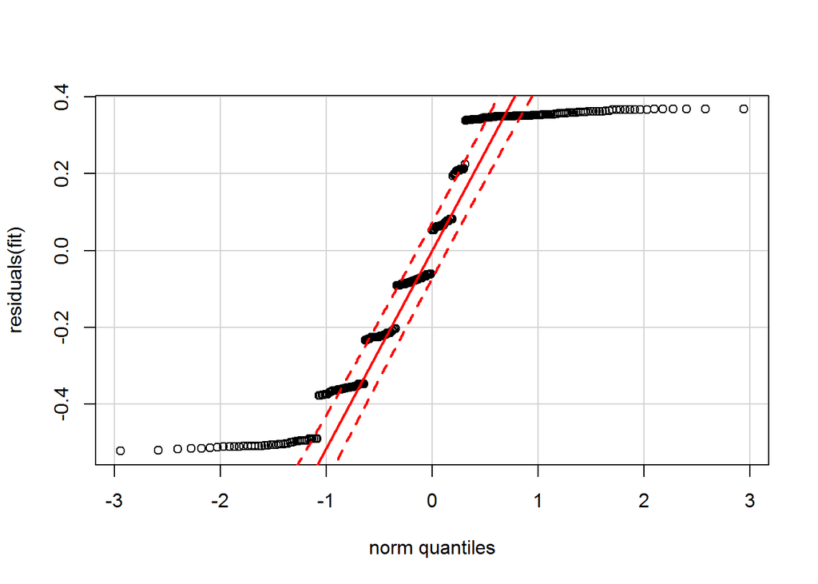

```
## NULL
## [1] "next"
## [1] 0.2
##
## Call:
## lm(formula = DTLoc$miseNorm ~ DTLoc$resLisse)
##
## Residuals:
##      Min       1Q   Median       3Q      Max
## -0.57733 -0.37693  0.02899  0.33408  0.47048
##
## Coefficients:
##                Estimate Std. Error t value Pr(>|t|)
## (Intercept)     0.47399    0.05428   8.732  < 2e-16 ***
## DTLoc$resLisse  0.37870    0.12219   3.099  0.00211 **
## ---
## Signif. codes:  0 '***' 0.001 '**' 0.01 '*' 0.05 '.' 0.1 ' ' 1
##
## Residual standard error: 0.3485 on 317 degrees of freedom
## Multiple R-squared:  0.02941,    Adjusted R-squared:  0.02635
## F-statistic: 9.606 on 1 and 317 DF,  p-value: 0.002113
```

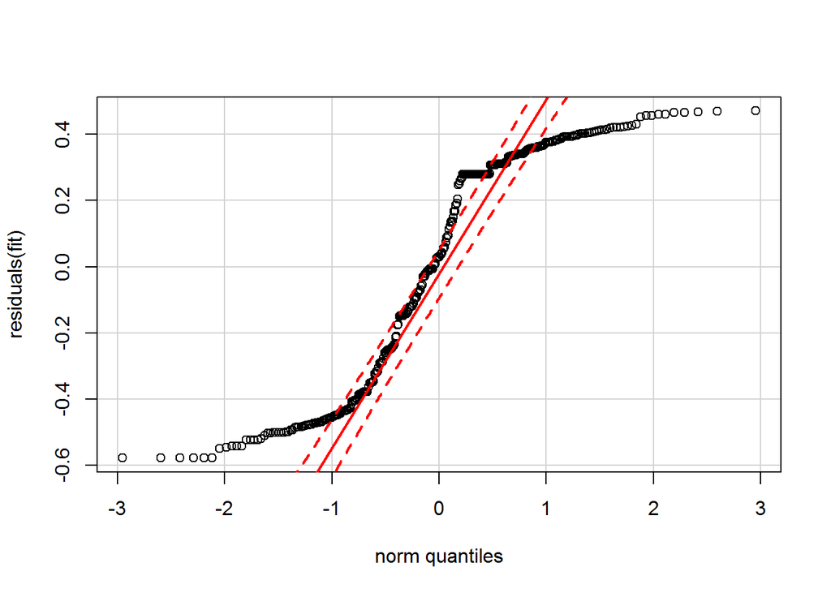

```
## NULL
## [1] "next"
## [1] 0.3
##
## Call:
## lm(formula = DTLoc$miseNorm ~ DTLoc$resLisse)
##
## Residuals:
##      Min       1Q   Median       3Q      Max
## -0.58285 -0.36219  0.05652  0.32477  0.40071
##
## Coefficients:
##                Estimate Std. Error t value Pr(>|t|)
## (Intercept)     0.55722    0.07631   7.302 5.38e-12 ***
## DTLoc$resLisse  0.23520    0.15182   1.549    0.123
## ---
## Signif. codes:  0 '***' 0.001 '**' 0.01 '*' 0.05 '.' 0.1 ' ' 1
##
## Residual standard error: 0.3465 on 216 degrees of freedom
## Multiple R-squared:  0.01099,    Adjusted R-squared:  0.006411
## F-statistic:   2.4 on 1 and 216 DF,  p-value: 0.1228
```

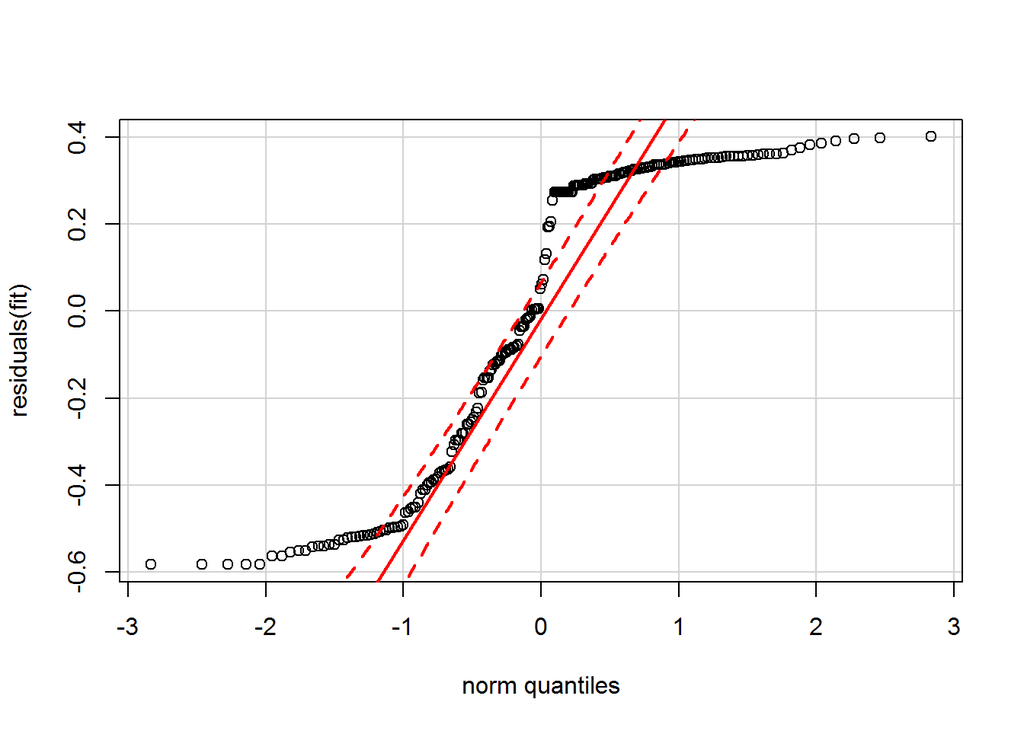

```
## NULL
## [1] "next"
## [1] 0.4
##
## Call:
## lm(formula = DTLoc$miseNorm ~ DTLoc$resLisse)
##
## Residuals:
##      Min       1Q   Median       3Q      Max
## -0.49803 -0.33294 -0.02425  0.39695  0.55846
##
## Coefficients:
##                Estimate Std. Error t value Pr(>|t|)
## (Intercept)     0.34960    0.09446   3.701 0.000276 ***
## DTLoc$resLisse  0.37617    0.16607   2.265 0.024560 *
## ---
## Signif. codes:  0 '***' 0.001 '**' 0.01 '*' 0.05 '.' 0.1 ' ' 1
##
## Residual standard error: 0.3542 on 203 degrees of freedom
## Multiple R-squared:  0.02465,    Adjusted R-squared:  0.01985
## F-statistic: 5.131 on 1 and 203 DF,  p-value: 0.02456
```

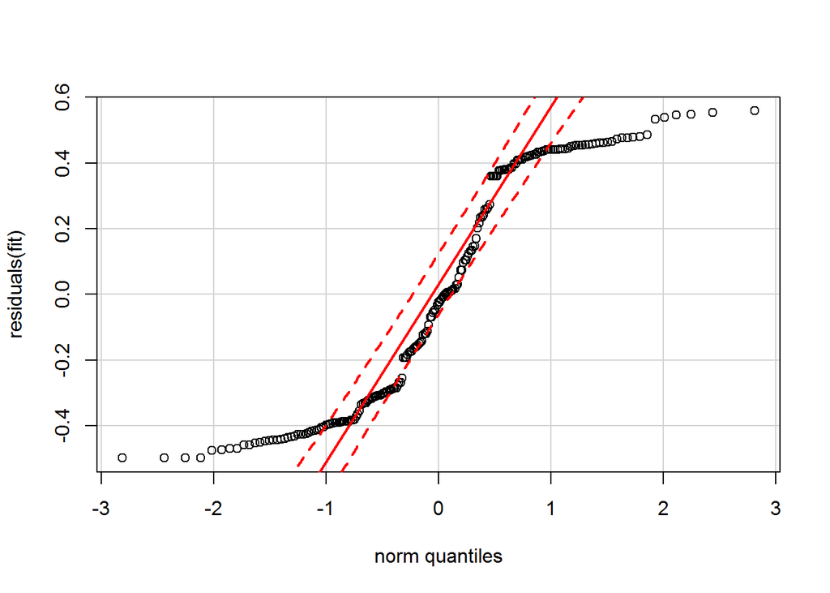

```
## NULL
## [1] "next"
## [1] 0.5
##
## Call:
## lm(formula = DTLoc$miseNorm ~ DTLoc$resLisse)
##
## Residuals:
##      Min       1Q   Median       3Q      Max
## -0.52251 -0.30627 -0.06855  0.36495  0.64860
##
## Coefficients:
##                Estimate Std. Error t value Pr(>|t|)
## (Intercept)      0.1394     0.1053   1.323 0.187284
## DTLoc$resLisse   0.6387     0.1688   3.784 0.000204 ***
## ---
## Signif. codes:  0 '***' 0.001 '**' 0.01 '*' 0.05 '.' 0.1 ' ' 1
##
## Residual standard error: 0.3379 on 197 degrees of freedom
## Multiple R-squared:  0.06777,    Adjusted R-squared:  0.06304
## F-statistic: 14.32 on 1 and 197 DF,  p-value: 0.0002044
```

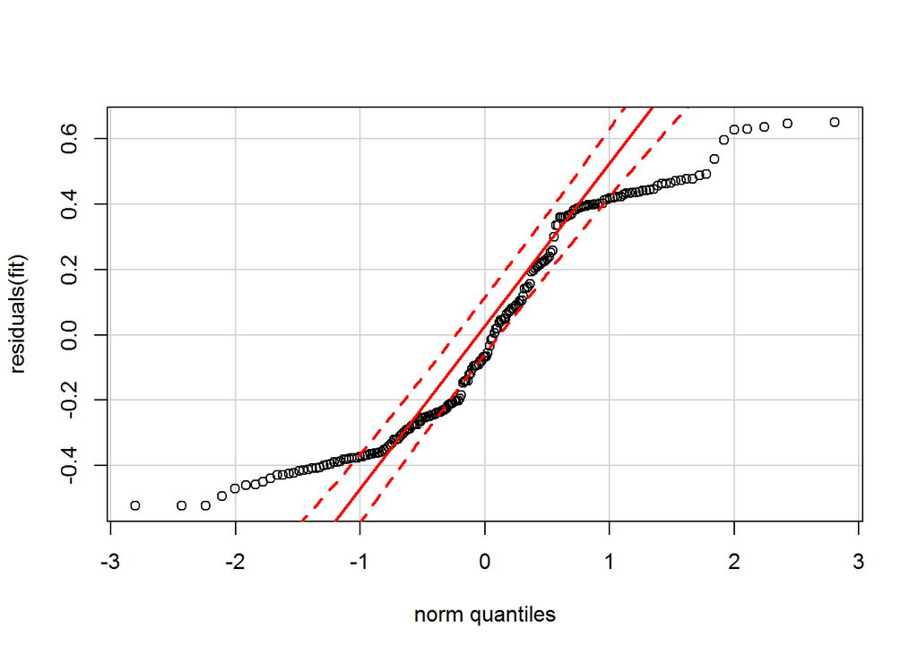

```
## NULL
## [1] "next"
## [1] 0.6
##
## Call:
## lm(formula = DTLoc$miseNorm ~ DTLoc$resLisse)
##
## Residuals:
##      Min       1Q   Median       3Q      Max
## -0.49732 -0.29094 -0.04125  0.35982  0.62309
##
## Coefficients:
##                Estimate Std. Error t value Pr(>|t|)
## (Intercept)      0.1760     0.1221   1.442  0.15127
## DTLoc$resLisse   0.5374     0.1768   3.039  0.00274 **
## ---
## Signif. codes:  0 '***' 0.001 '**' 0.01 '*' 0.05 '.' 0.1 ' ' 1
##
## Residual standard error: 0.3259 on 171 degrees of freedom
## Multiple R-squared:  0.05126,    Adjusted R-squared:  0.04571
## F-statistic: 9.238 on 1 and 171 DF,  p-value: 0.002743
```

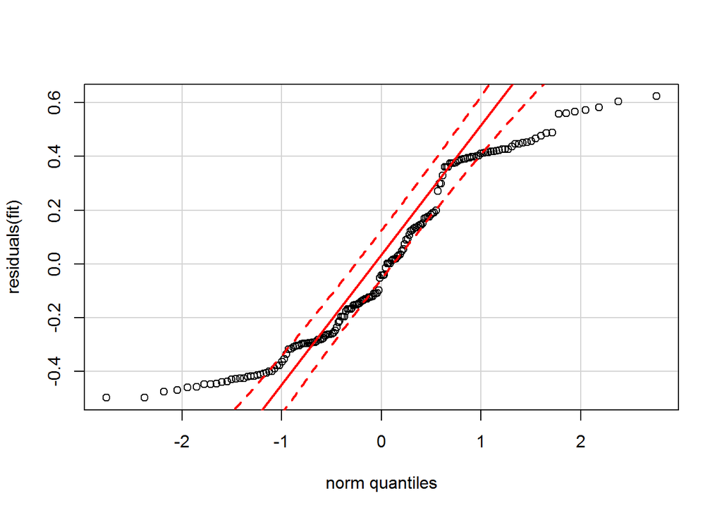

```
## NULL
## [1] "next"
## [1] 0.7
##
## Call:
## lm(formula = DTLoc$miseNorm ~ DTLoc$resLisse)
##
## Residuals:
##      Min       1Q   Median       3Q      Max
## -0.48285 -0.30837 -0.02578  0.37793  0.50069
##
## Coefficients:
##                Estimate Std. Error t value Pr(>|t|)
## (Intercept)      0.3552     0.1442   2.463   0.0148 *
## DTLoc$resLisse   0.3119     0.1978   1.577   0.1167
## ---
## Signif. codes:  0 '***' 0.001 '**' 0.01 '*' 0.05 '.' 0.1 ' ' 1
##
## Residual standard error: 0.3308 on 167 degrees of freedom
## Multiple R-squared:  0.01467,    Adjusted R-squared:  0.008773
## F-statistic: 2.487 on 1 and 167 DF,  p-value: 0.1167
```

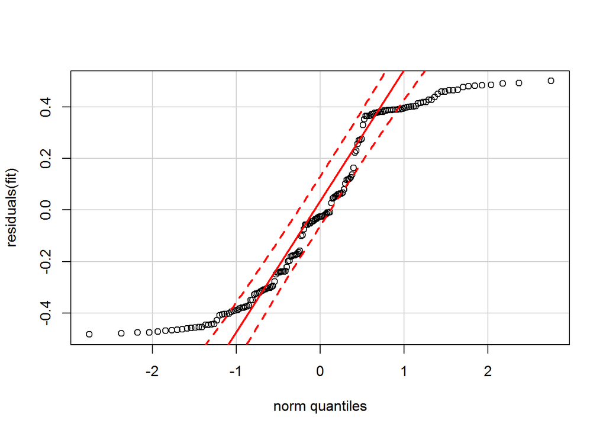

```
## NULL
## [1] "next"
## [1] 0.8
##
## Call:
## lm(formula = DTLoc$miseNorm ~ DTLoc$resLisse)
##
## Residuals:
##     Min      1Q  Median      3Q     Max
## -0.4849 -0.3083 -0.0334  0.3866  0.4573
##
## Coefficients:
##                Estimate Std. Error t value Pr(>|t|)
## (Intercept)      0.3695     0.2092   1.766   0.0798 .
## DTLoc$resLisse   0.2802     0.2712   1.033   0.3035
## ---
## Signif. codes:  0 '***' 0.001 '**' 0.01 '*' 0.05 '.' 0.1 ' ' 1
##
## Residual standard error: 0.3238 on 127 degrees of freedom
## Multiple R-squared:  0.008335,   Adjusted R-squared:  0.000527
## F-statistic: 1.067 on 1 and 127 DF,  p-value: 0.3035
```

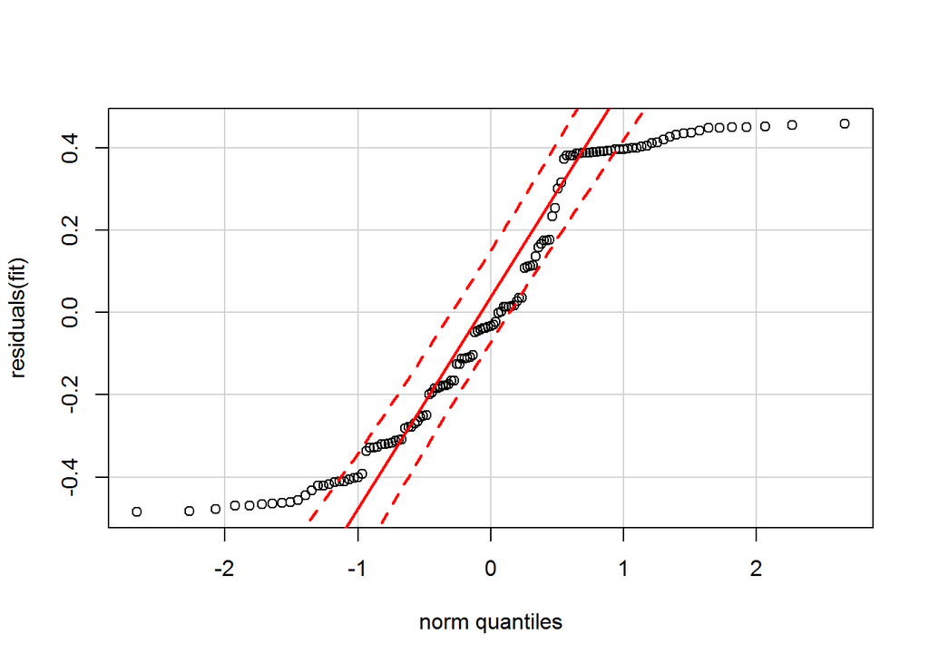

```
## NULL
## [1] "next"
## [1] 0.9
##
## Call:
## lm(formula = DTLoc$miseNorm ~ DTLoc$resLisse)
##
## Residuals:
##      Min       1Q   Median       3Q      Max
## -0.52442 -0.25292 -0.05683  0.33230  0.49478
##
## Coefficients:
##                Estimate Std. Error t value Pr(>|t|)
## (Intercept)     -0.1655     0.3521  -0.470    0.640
## DTLoc$resLisse   0.9236     0.4260   2.168    0.033 *
## ---
## Signif. codes:  0 '***' 0.001 '**' 0.01 '*' 0.05 '.' 0.1 ' ' 1
##
## Residual standard error: 0.3112 on 85 degrees of freedom
## Multiple R-squared:  0.05239,    Adjusted R-squared:  0.04124
## F-statistic: 4.699 on 1 and 85 DF,  p-value: 0.03297
```

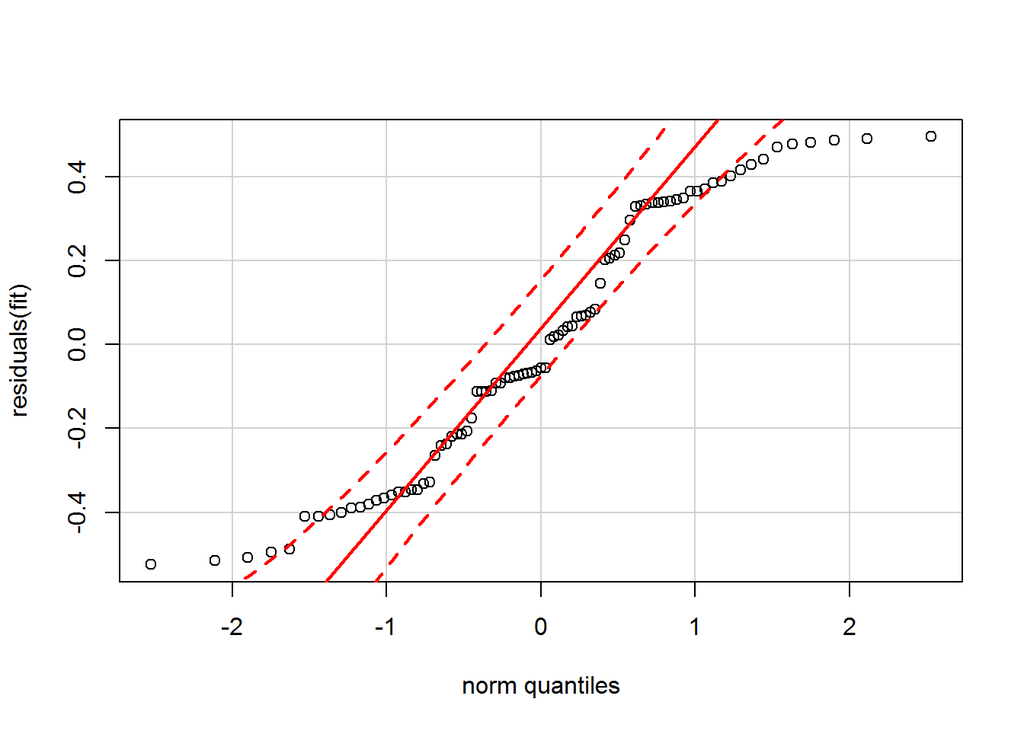

```
## NULL
## [1] "next"
## [1] 1
##
## Call:
## lm(formula = DTLoc$miseNorm ~ DTLoc$resLisse)
##
## Residuals:
##      Min       1Q   Median       3Q      Max
## -0.46890 -0.25626 -0.03041  0.27938  0.42886
##
## Coefficients:
##                Estimate Std. Error t value Pr(>|t|)
## (Intercept)      0.3256     0.6922   0.470    0.640
## DTLoc$resLisse   0.3013     0.7828   0.385    0.702
##
## Residual standard error: 0.3149 on 48 degrees of freedom
## Multiple R-squared:  0.003077,   Adjusted R-squared:  -0.01769
## F-statistic: 0.1481 on 1 and 48 DF,  p-value: 0.702
```

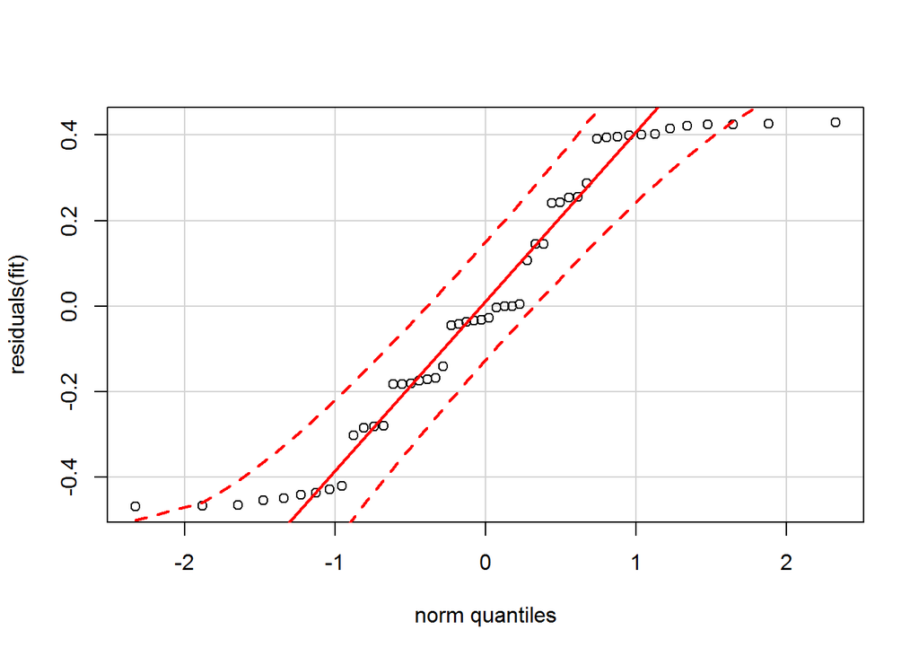

```
## NULL
## [1] "next"
```

```
## [1] "Motrice"
```

```
## [1] 0
##
## Call:
## lm(formula = DTLoc$miseNorm ~ DTLoc$resLisse)
##
## Residuals:
##     Min      1Q  Median      3Q     Max
## -0.6954 -0.2144  0.1393  0.1841  0.2470
##
## Coefficients:
##                Estimate Std. Error t value Pr(>|t|)
## (Intercept)     0.71002    0.08514    8.34 3.96e-13 ***
## DTLoc$resLisse  0.57480    0.41048    1.40    0.164
## ---
## Signif. codes:  0 '***' 0.001 '**' 0.01 '*' 0.05 '.' 0.1 ' ' 1
##
## Residual standard error: 0.2567 on 101 degrees of freedom
## Multiple R-squared:  0.01904,    Adjusted R-squared:  0.009332
## F-statistic: 1.961 on 1 and 101 DF,  p-value: 0.1645
```

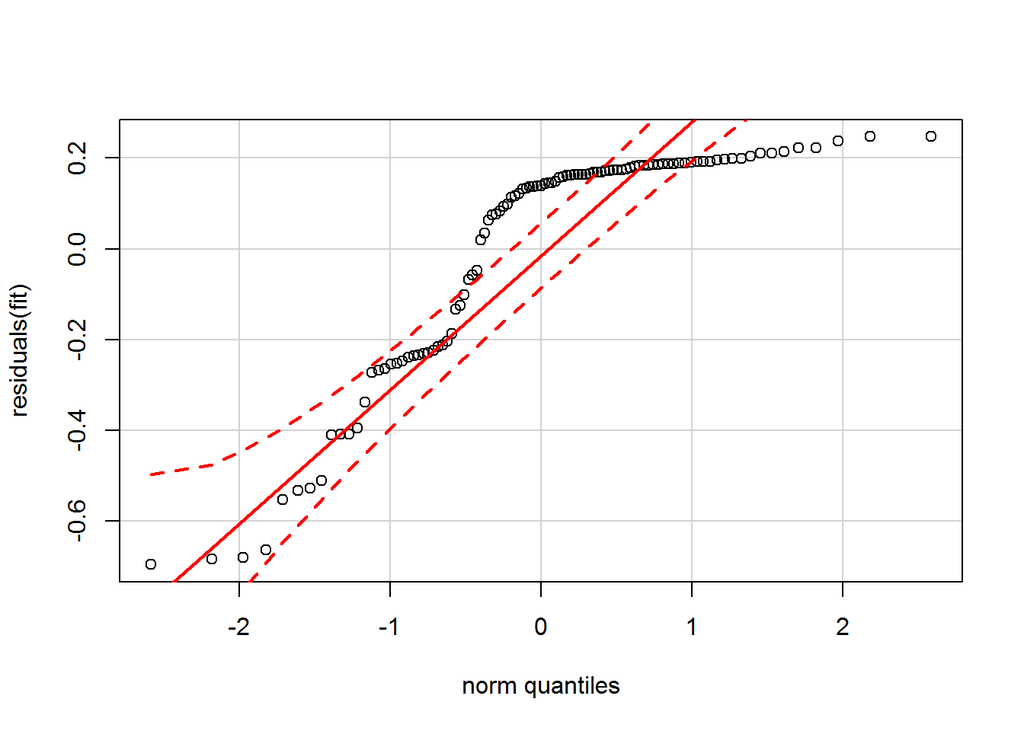

```
## NULL
## [1] "next"
## [1] 0.1
##
## Call:
## lm(formula = DTLoc$miseNorm ~ DTLoc$resLisse)
##
## Residuals:
##      Min       1Q   Median       3Q      Max
## -0.61132 -0.29214  0.01591  0.32632  0.43781
##
## Coefficients:
##                Estimate Std. Error t value Pr(>|t|)
## (Intercept)     0.80850    0.09803   8.248    3e-14 ***
## DTLoc$resLisse -0.51272    0.34024  -1.507    0.134
## ---
## Signif. codes:  0 '***' 0.001 '**' 0.01 '*' 0.05 '.' 0.1 ' ' 1
##
## Residual standard error: 0.3219 on 184 degrees of freedom
## Multiple R-squared:  0.01219,    Adjusted R-squared:  0.006823
## F-statistic: 2.271 on 1 and 184 DF,  p-value: 0.1335
```

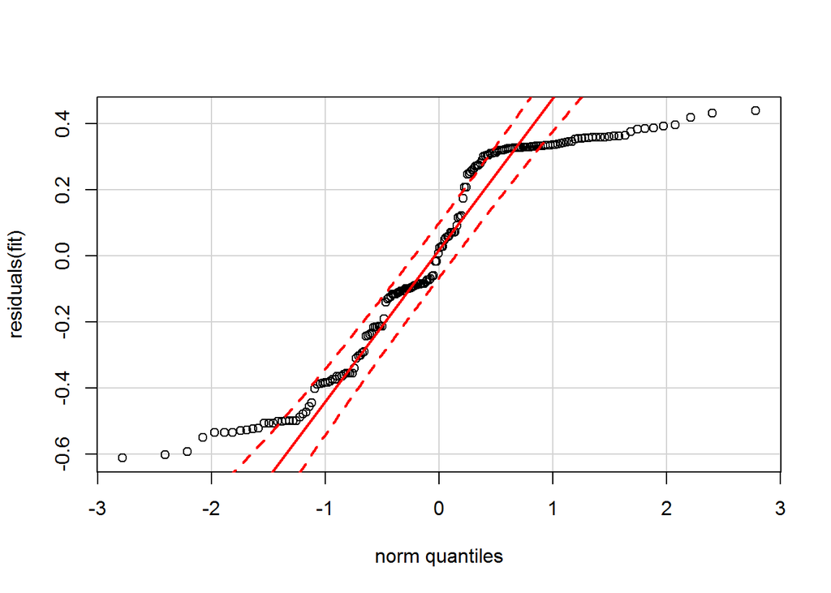

```
## NULL
## [1] "next"
## [1] 0.2
##
## Call:
## lm(formula = DTLoc$miseNorm ~ DTLoc$resLisse)
##
## Residuals:
##      Min       1Q   Median       3Q      Max
## -0.54617 -0.24674  0.04334  0.33003  0.36039
##
## Coefficients:
##                Estimate Std. Error t value Pr(>|t|)
## (Intercept)     0.62501    0.08615   7.255 3.37e-12 ***
## DTLoc$resLisse  0.10983    0.21937   0.501    0.617
## ---
## Signif. codes:  0 '***' 0.001 '**' 0.01 '*' 0.05 '.' 0.1 ' ' 1
##
## Residual standard error: 0.3249 on 304 degrees of freedom
## Multiple R-squared:  0.0008239,  Adjusted R-squared:  -0.002463
## F-statistic: 0.2507 on 1 and 304 DF,  p-value: 0.617
```

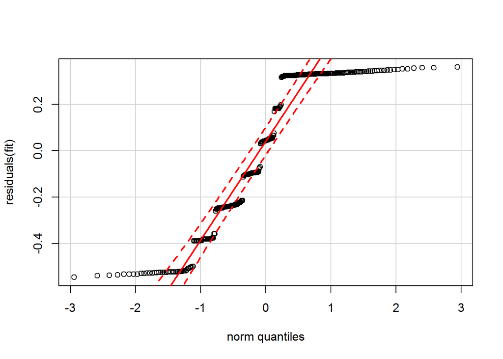

```
## NULL
## [1] "next"
## [1] 0.3
##
## Call:
## lm(formula = DTLoc$miseNorm ~ DTLoc$resLisse)
##
## Residuals:
##      Min       1Q   Median       3Q      Max
## -0.59932 -0.27711  0.01594  0.30973  0.42876
##
## Coefficients:
##                Estimate Std. Error t value Pr(>|t|)
## (Intercept)     0.50492    0.08354   6.044 3.88e-09 ***
## DTLoc$resLisse  0.37112    0.17586   2.110   0.0355 *
## ---
## Signif. codes:  0 '***' 0.001 '**' 0.01 '*' 0.05 '.' 0.1 ' ' 1
##
## Residual standard error: 0.3251 on 346 degrees of freedom
## Multiple R-squared:  0.01271,    Adjusted R-squared:  0.009855
## F-statistic: 4.454 on 1 and 346 DF,  p-value: 0.03554
```

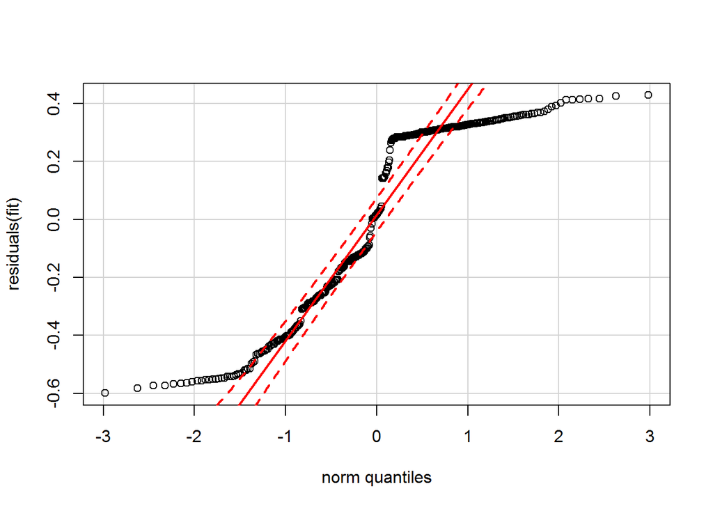

```
## NULL
## [1] "next"
## [1] 0.4
##
## Call:
## lm(formula = DTLoc$miseNorm ~ DTLoc$resLisse)
##
## Residuals:
##      Min       1Q   Median       3Q      Max
## -0.57986 -0.25981 -0.05585  0.33615  0.53830
##
## Coefficients:
##                Estimate Std. Error t value Pr(>|t|)
## (Intercept)      0.3199     0.0943   3.393 0.000788 ***
## DTLoc$resLisse   0.5566     0.1655   3.363 0.000876 ***
## ---
## Signif. codes:  0 '***' 0.001 '**' 0.01 '*' 0.05 '.' 0.1 ' ' 1
##
## Residual standard error: 0.3158 on 291 degrees of freedom
## Multiple R-squared:  0.0374, Adjusted R-squared:  0.03409
## F-statistic: 11.31 on 1 and 291 DF,  p-value: 0.0008757
```

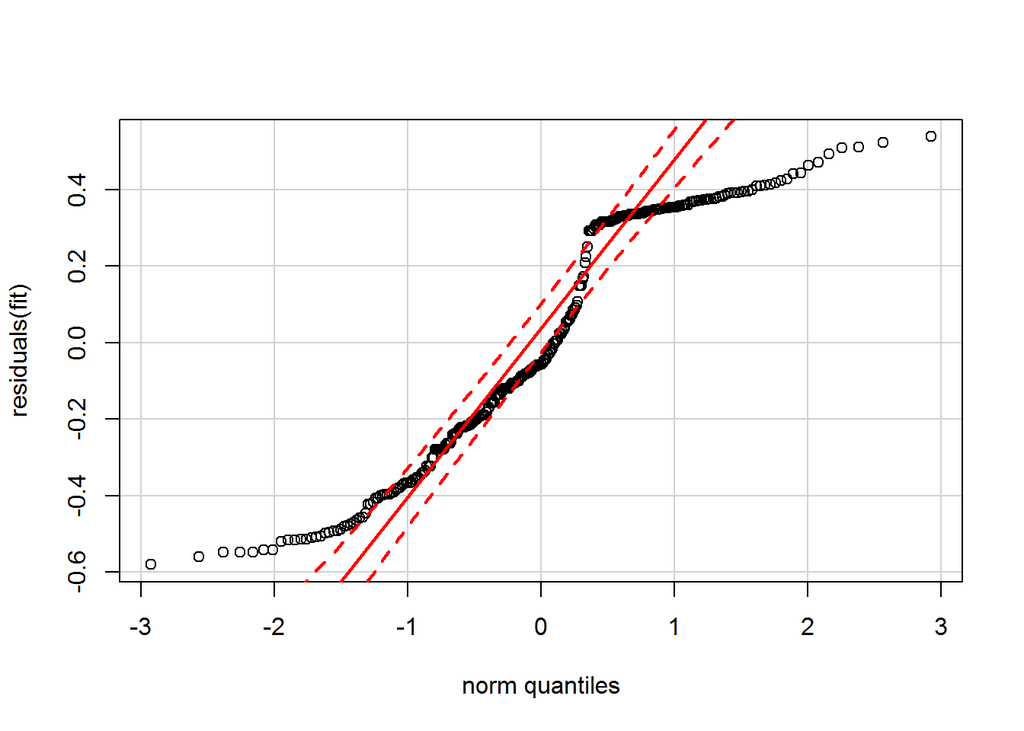

```
## NULL
## [1] "next"
## [1] 0.5
##
## Call:
## lm(formula = DTLoc$miseNorm ~ DTLoc$resLisse)
##
## Residuals:
##      Min       1Q   Median       3Q      Max
## -0.49044 -0.29600 -0.04962  0.37880  0.43173
##
## Coefficients:
##                Estimate Std. Error t value Pr(>|t|)
## (Intercept)      0.5154     0.1089   4.732 3.83e-06 ***
## DTLoc$resLisse   0.1520     0.1742   0.873    0.384
## ---
## Signif. codes:  0 '***' 0.001 '**' 0.01 '*' 0.05 '.' 0.1 ' ' 1
##
## Residual standard error: 0.3213 on 236 degrees of freedom
## Multiple R-squared:  0.003217,   Adjusted R-squared:  -0.001006
## F-statistic: 0.7618 on 1 and 236 DF,  p-value: 0.3837
```

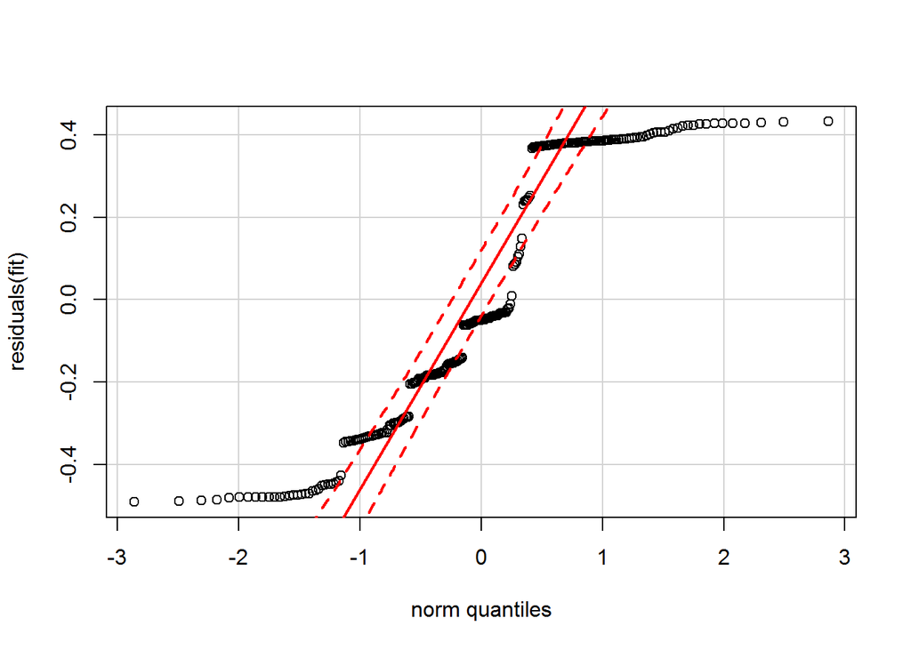

```
## NULL
## [1] "next"
## [1] 0.6
##
## Call:
## lm(formula = DTLoc$miseNorm ~ DTLoc$resLisse)
##
## Residuals:
##      Min       1Q   Median       3Q      Max
## -0.44144 -0.28250 -0.00737  0.32114  0.52236
##
## Coefficients:
##                Estimate Std. Error t value Pr(>|t|)
## (Intercept)      0.3456     0.1365   2.531   0.0123 *
## DTLoc$resLisse   0.2865     0.2012   1.424   0.1564
## ---
## Signif. codes:  0 '***' 0.001 '**' 0.01 '*' 0.05 '.' 0.1 ' ' 1
##
## Residual standard error: 0.3158 on 163 degrees of freedom
## Multiple R-squared:  0.01228,    Adjusted R-squared:  0.006224
## F-statistic: 2.027 on 1 and 163 DF,  p-value: 0.1564
```

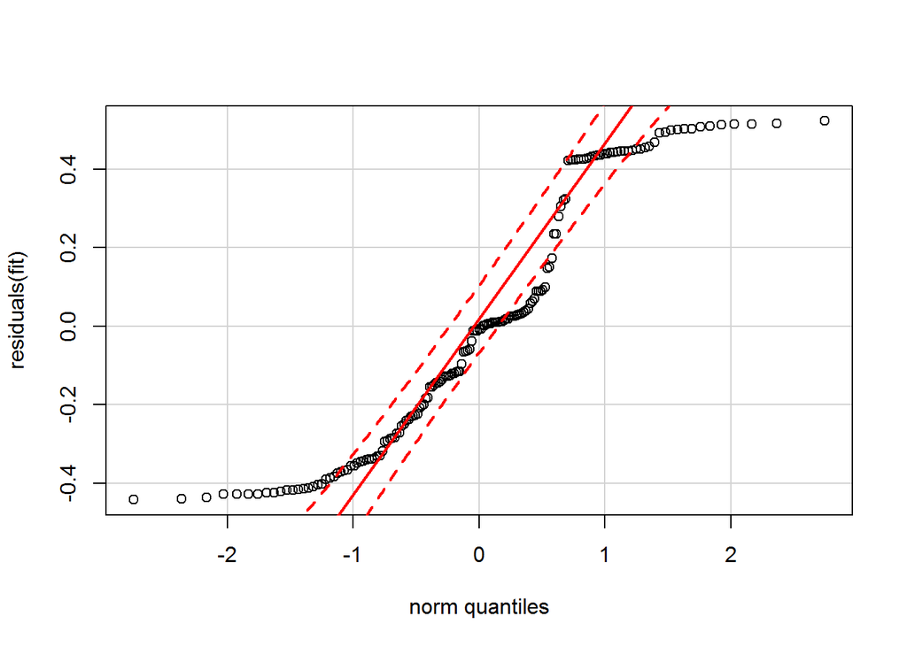

```
## NULL
## [1] "next"
## [1] 0.7
##
## Call:
## lm(formula = DTLoc$miseNorm ~ DTLoc$resLisse)
##
## Residuals:
##      Min       1Q   Median       3Q      Max
## -0.45168 -0.30049 -0.01497  0.41297  0.44047
##
## Coefficients:
##                Estimate Std. Error t value Pr(>|t|)
## (Intercept)      0.4964     0.2157   2.301   0.0231 *
## DTLoc$resLisse   0.1124     0.2960   0.380   0.7049
## ---
## Signif. codes:  0 '***' 0.001 '**' 0.01 '*' 0.05 '.' 0.1 ' ' 1
##
## Residual standard error: 0.3352 on 117 degrees of freedom
## Multiple R-squared:  0.00123,    Adjusted R-squared:  -0.007307
## F-statistic: 0.1441 on 1 and 117 DF,  p-value: 0.7049
```

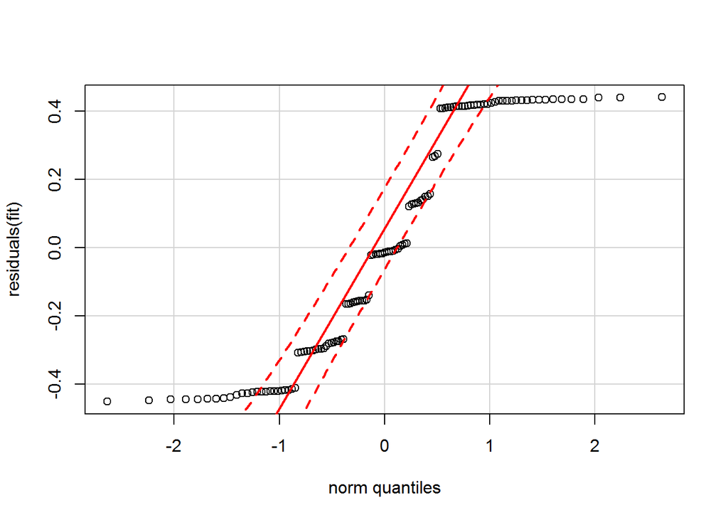

```
## NULL
## [1] "next"
## [1] 0.8
##
## Call:
## lm(formula = DTLoc$miseNorm ~ DTLoc$resLisse)
##
## Residuals:
##      Min       1Q   Median       3Q      Max
## -0.45125 -0.28164 -0.00081  0.30962  0.45839
##
## Coefficients:
##                Estimate Std. Error t value Pr(>|t|)
## (Intercept)      0.7275     0.3671   1.982   0.0511 .
## DTLoc$resLisse  -0.2082     0.4706  -0.442   0.6594
## ---
## Signif. codes:  0 '***' 0.001 '**' 0.01 '*' 0.05 '.' 0.1 ' ' 1
##
## Residual standard error: 0.3277 on 76 degrees of freedom
## Multiple R-squared:  0.00257,    Adjusted R-squared:  -0.01055
## F-statistic: 0.1958 on 1 and 76 DF,  p-value: 0.6594
```

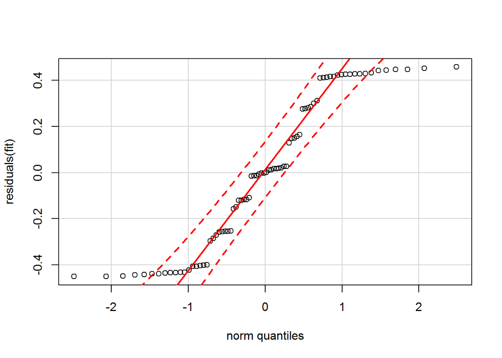

```
## NULL
## [1] "next"
## [1] 0.9
##
## Call:
## lm(formula = DTLoc$miseNorm ~ DTLoc$resLisse)
##
## Residuals:
##      Min       1Q   Median       3Q      Max
## -0.53733 -0.14285  0.03421  0.32397  0.36158
##
## Coefficients:
##                Estimate Std. Error t value Pr(>|t|)
## (Intercept)      0.4067     0.7826   0.520    0.607
## DTLoc$resLisse   0.3032     0.9393   0.323    0.749
##
## Residual standard error: 0.31 on 34 degrees of freedom
## Multiple R-squared:  0.003054,   Adjusted R-squared:  -0.02627
## F-statistic: 0.1042 on 1 and 34 DF,  p-value: 0.7489
```

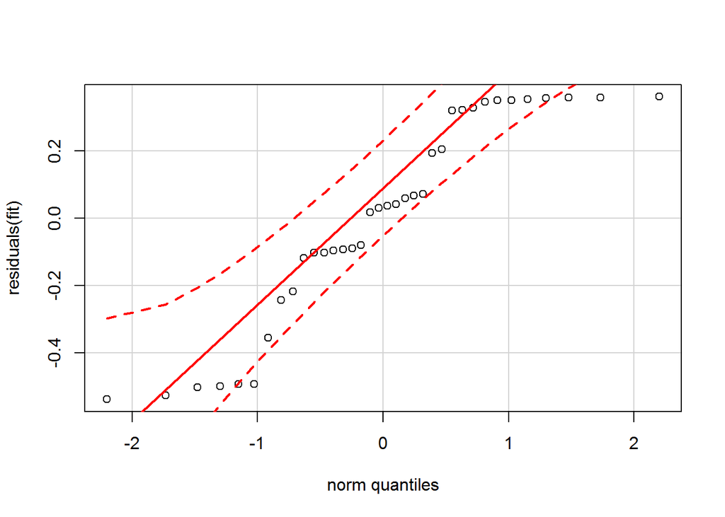

```
## NULL
## [1] "next"
## [1] 1
##
## Call:
## lm(formula = DTLoc$miseNorm ~ DTLoc$resLisse)
##
## Residuals:
##     Min      1Q  Median      3Q     Max
## -0.6578 -0.1400  0.1900  0.2244  0.2745
##
## Coefficients:
##                Estimate Std. Error t value Pr(>|t|)
## (Intercept)      0.1839     1.1076   0.166    0.869
## DTLoc$resLisse   0.6679     1.2369   0.540    0.593
##
## Residual standard error: 0.32 on 30 degrees of freedom
## Multiple R-squared:  0.009628,   Adjusted R-squared:  -0.02338
## F-statistic: 0.2916 on 1 and 30 DF,  p-value: 0.5932
```

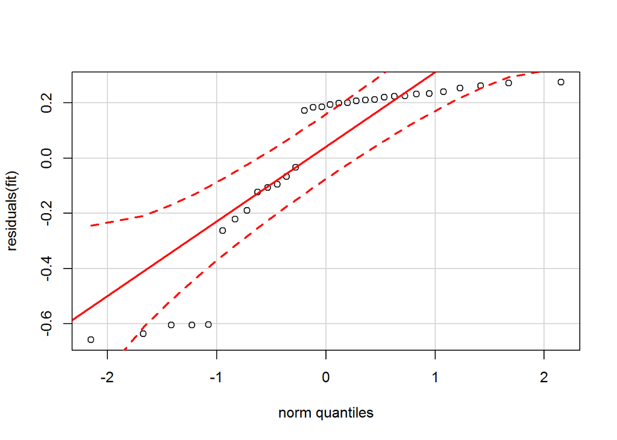

```
## NULL
## [1] "next"
```

```
## [1] "Senso"
```

```
## [1] 0
##
## Call:
## lm(formula = DTLoc$miseNorm ~ DTLoc$resLisse)
##
## Residuals:
##      Min       1Q   Median       3Q      Max
## -0.78331  0.07223  0.07581  0.07780  0.07985
##
## Coefficients:
##                Estimate Std. Error t value Pr(>|t|)
## (Intercept)     0.91905    0.04029   22.81   <2e-16 ***
## DTLoc$resLisse  0.02322    0.15433    0.15    0.881
## ---
## Signif. codes:  0 '***' 0.001 '**' 0.01 '*' 0.05 '.' 0.1 ' ' 1
##
## Residual standard error: 0.2255 on 134 degrees of freedom
## Multiple R-squared:  0.0001689,  Adjusted R-squared:  -0.007293
## F-statistic: 0.02264 on 1 and 134 DF,  p-value: 0.8806
```

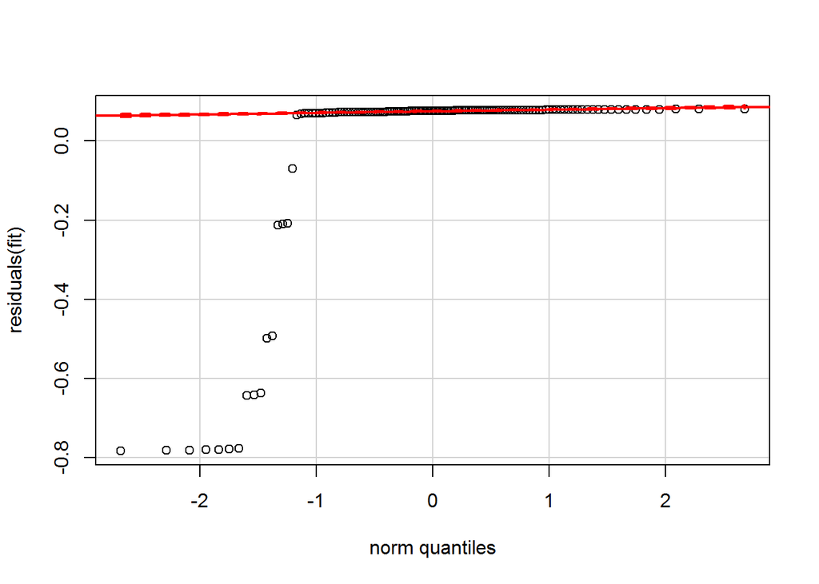

```
## NULL
## [1] "next"
## [1] 0.1
##
## Call:
## lm(formula = DTLoc$miseNorm ~ DTLoc$resLisse)
##
## Residuals:
##     Min      1Q  Median      3Q     Max
## -0.7697 -0.1762  0.1138  0.2192  0.3661
##
## Coefficients:
##                Estimate Std. Error t value Pr(>|t|)
## (Intercept)      0.5789     0.0490  11.816  < 2e-16 ***
## DTLoc$resLisse   0.7181     0.1486   4.831 2.08e-06 ***
## ---
## Signif. codes:  0 '***' 0.001 '**' 0.01 '*' 0.05 '.' 0.1 ' ' 1
##
## Residual standard error: 0.3044 on 332 degrees of freedom
## Multiple R-squared:  0.06568,    Adjusted R-squared:  0.06287
## F-statistic: 23.34 on 1 and 332 DF,  p-value: 2.077e-06
```

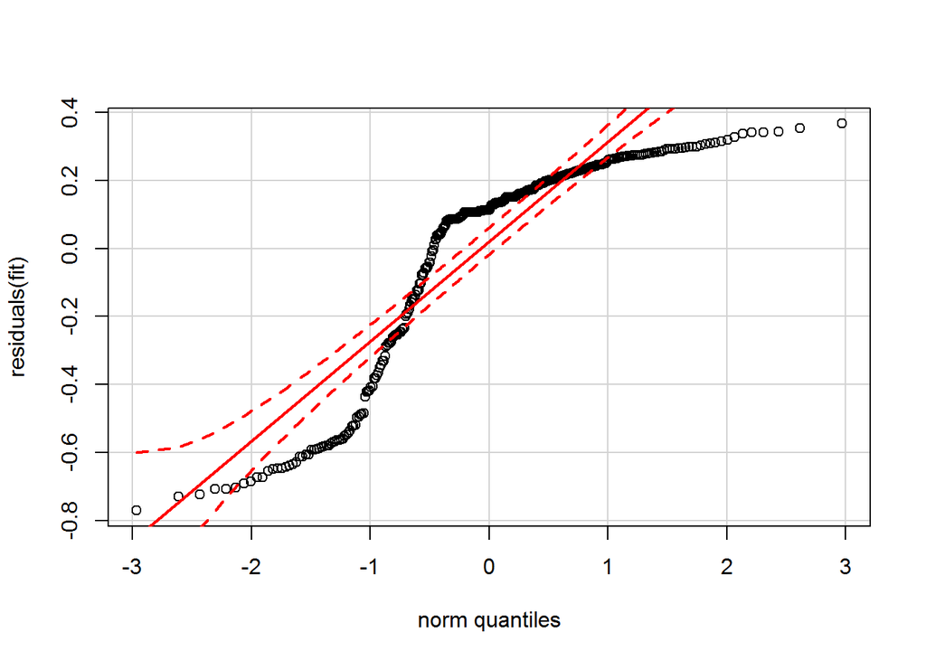

```
## NULL
## [1] "next"
## [1] 0.2
##
## Call:
## lm(formula = DTLoc$miseNorm ~ DTLoc$resLisse)
##
## Residuals:
##     Min      1Q  Median      3Q     Max
## -0.6944 -0.3298  0.1552  0.2960  0.5089
##
## Coefficients:
##                Estimate Std. Error t value Pr(>|t|)
## (Intercept)     0.41156    0.05658   7.274 1.27e-12 ***
## DTLoc$resLisse  0.58568    0.11684   5.013 7.33e-07 ***
## ---
## Signif. codes:  0 '***' 0.001 '**' 0.01 '*' 0.05 '.' 0.1 ' ' 1
##
## Residual standard error: 0.3437 on 527 degrees of freedom
## Multiple R-squared:  0.04551,    Adjusted R-squared:  0.0437
## F-statistic: 25.13 on 1 and 527 DF,  p-value: 7.334e-07
```

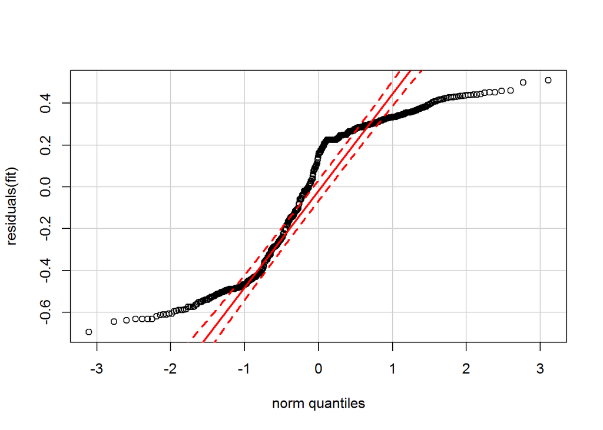

```
## NULL
## [1] "next"
## [1] 0.3
##
## Call:
## lm(formula = DTLoc$miseNorm ~ DTLoc$resLisse)
##
## Residuals:
##      Min       1Q   Median       3Q      Max
## -0.58749 -0.34966 -0.03194  0.36526  0.63289
##
## Coefficients:
##                Estimate Std. Error t value Pr(>|t|)
## (Intercept)     0.27559    0.08252   3.340 0.000901 ***
## DTLoc$resLisse  0.52607    0.13491   3.899 0.000110 ***
## ---
## Signif. codes:  0 '***' 0.001 '**' 0.01 '*' 0.05 '.' 0.1 ' ' 1
##
## Residual standard error: 0.3558 on 500 degrees of freedom
## Multiple R-squared:  0.02951,    Adjusted R-squared:  0.02757
## F-statistic: 15.21 on 1 and 500 DF,  p-value: 0.0001096
```

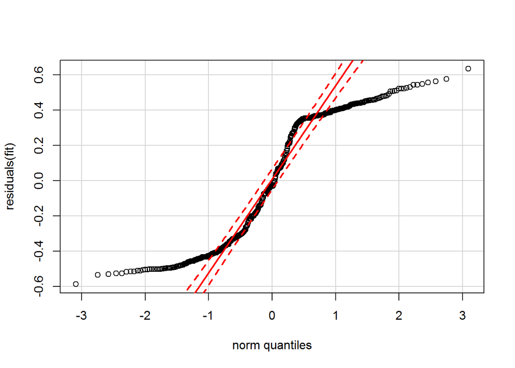

```
## NULL
## [1] "next"
## [1] 0.4
##
## Call:
## lm(formula = DTLoc$miseNorm ~ DTLoc$resLisse)
##
## Residuals:
##     Min      1Q  Median      3Q     Max
## -0.4061 -0.3250 -0.1286  0.3632  0.6463
##
## Coefficients:
##                Estimate Std. Error t value Pr(>|t|)
## (Intercept)      0.1994     0.1244   1.602   0.1102
## DTLoc$resLisse   0.3795     0.1712   2.217   0.0274 *
## ---
## Signif. codes:  0 '***' 0.001 '**' 0.01 '*' 0.05 '.' 0.1 ' ' 1
##
## Residual standard error: 0.3465 on 278 degrees of freedom
## Multiple R-squared:  0.01737,    Adjusted R-squared:  0.01383
## F-statistic: 4.914 on 1 and 278 DF,  p-value: 0.02745
```

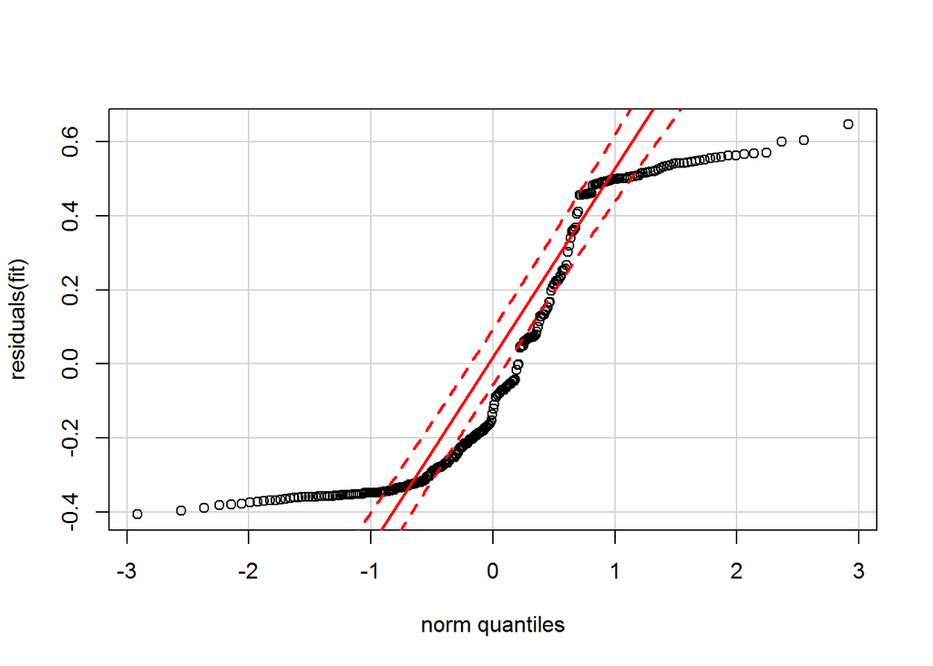

```
## NULL
## [1] "next"
## [1] 0.5
##
## Call:
## lm(formula = DTLoc$miseNorm ~ DTLoc$resLisse)
##
## Residuals:
##     Min      1Q  Median      3Q     Max
## -0.2911 -0.2413 -0.1482  0.1688  0.6934
##
## Coefficients:
##                Estimate Std. Error t value Pr(>|t|)
## (Intercept)    -0.05816    0.21723  -0.268   0.7894
## DTLoc$resLisse  0.52376    0.26535   1.974   0.0507 .
## ---
## Signif. codes:  0 '***' 0.001 '**' 0.01 '*' 0.05 '.' 0.1 ' ' 1
##
## Residual standard error: 0.3121 on 121 degrees of freedom
## Multiple R-squared:  0.03119,    Adjusted R-squared:  0.02319
## F-statistic: 3.896 on 1 and 121 DF,  p-value: 0.05068
```

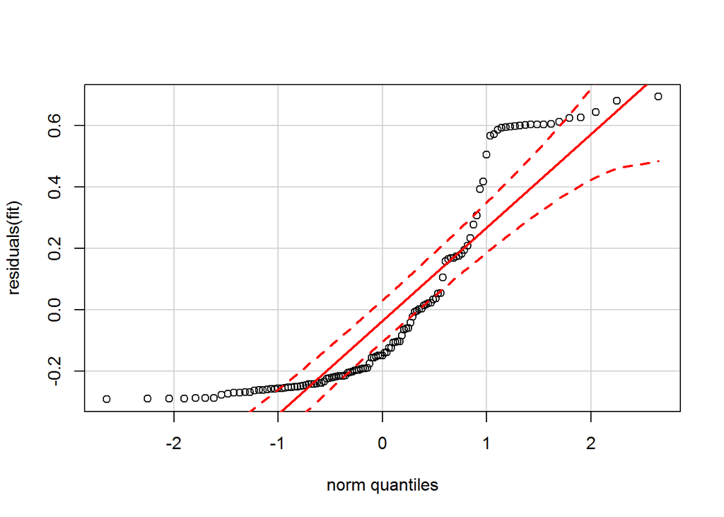

```
## NULL
## [1] "next"
## [1] 0.6
##
## Call:
## lm(formula = DTLoc$miseNorm ~ DTLoc$resLisse)
##
## Residuals:
##     Min      1Q  Median      3Q     Max
## -0.2691 -0.1799 -0.1045  0.0471  0.7533
##
## Coefficients:
##                Estimate Std. Error t value Pr(>|t|)
## (Intercept)     -0.1964     0.3546  -0.554    0.583
## DTLoc$resLisse   0.6326     0.4195   1.508    0.139
##
## Residual standard error: 0.2863 on 42 degrees of freedom
## Multiple R-squared:  0.05138,    Adjusted R-squared:  0.02879
## F-statistic: 2.275 on 1 and 42 DF,  p-value: 0.139
```

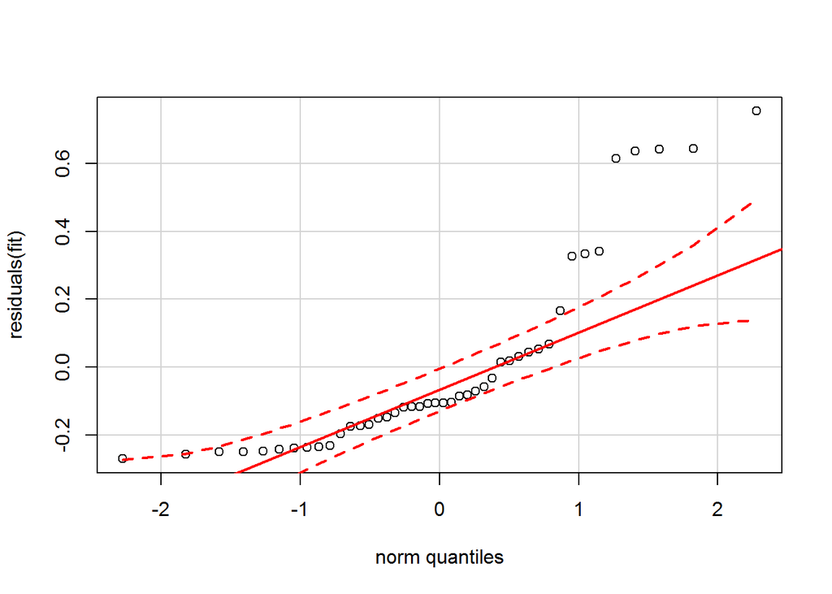

```
## NULL
## [1] "next"
## [1] 0.7
## [1] 0.8
## [1] 0.9
## [1] 1
```

## Resume des essais

```
## [1] "Logique"
```

```
##     NbObservations   DiffObj NbJoueurs   Coef      R2 pValueModele
##  1:            162 0.3112733        35  0.700 0.05900    0.0018 **
##  2:            305 0.3394522        54 -0.069 0.00071      0.64 :(
##  3:            319 0.3688160        71  0.380 0.02900    0.0021 **
##  4:            218 0.3991849        70  0.240 0.01100      0.12 :(
##  5:            205 0.4303494        66  0.380 0.02500      0.025 *
##  6:            199 0.4620758        58  0.640 0.06800    2e-04 ***
##  7:            173 0.4941123        47  0.540 0.05100    0.0027 **
##  8:            169 0.5261973        42  0.310 0.01500      0.12 :(
##  9:            129 0.5580673        38  0.280 0.00830       0.3 :(
## 10:             87 0.5894662        26  0.920 0.05200      0.033 *
## 11:             50 0.6201526        18  0.300 0.00310       0.7 :(
##     normResidus
##  1: 9.4e-07 ***
##  2: 2.2e-16 ***
##  3:   5e-15 ***
##  4: 4.2e-14 ***
##  5: 1.5e-11 ***
##  6: 3.2e-09 ***
##  7: 1.2e-07 ***
##  8: 3.5e-09 ***
##  9: 6.9e-08 ***
## 10: 0.00039 ***
## 11: 0.00089 ***
```

```
## [1] "Motrice"
```

```
##     NbObservations   DiffObj NbJoueurs  Coef      R2 pValueModele
##  1:            103 0.3840776        30  0.57 0.01900      0.16 :(
##  2:            186 0.4049587        40 -0.51 0.01200      0.13 :(
##  3:            306 0.4261895        63  0.11 0.00082      0.62 :(
##  4:            348 0.4476959        66  0.37 0.01300      0.036 *
##  5:            293 0.4693997        65  0.56 0.03700  0.00088 ***
##  6:            238 0.4912200        58  0.15 0.00320      0.38 :(
##  7:            165 0.5130737        50  0.29 0.01200      0.16 :(
##  8:            119 0.5348776        36  0.11 0.00120       0.7 :(
##  9:             78 0.5565490        25 -0.21 0.00260      0.66 :(
## 10:             36 0.5780072        16  0.30 0.00310      0.75 :(
## 11:             32 0.5991750         8  0.67 0.00960      0.59 :(
##     normResidus
##  1: 8.7e-11 ***
##  2: 2.3e-10 ***
##  3: 8.9e-17 ***
##  4: 1.7e-16 ***
##  5: 1.9e-11 ***
##  6: 4.4e-13 ***
##  7: 9.6e-09 ***
##  8: 5.1e-09 ***
##  9: 7.1e-06 ***
## 10:   0.0021 **
## 11: 1.1e-05 ***
```

```
## [1] "Senso"
```

```
##     NbObservations   DiffObj NbJoueurs  Coef      R2 pValueModele
##  1:            136 0.2074716        51 0.023 0.00017      0.88 :(
##  2:            334 0.3047975        66 0.720 0.06600  2.1e-06 ***
##  3:            529 0.4233889        70 0.590 0.04600  7.3e-07 ***
##  4:            502 0.5515169        70 0.530 0.03000  0.00011 ***
##  5:            280 0.6731529        61 0.380 0.01700      0.027 *
##  6:            123 0.7752433        44 0.520 0.03100      0.051 .
##  7:             44 0.8524361        22 0.630 0.05100      0.14 :(
##  8:             11 0.9063206         7    NA      NA           NA
##  9:              1 0.9418705         1    NA      NA           NA
## 10:              0        NA         0    NA      NA           NA
## 11:              0        NA         0    NA      NA           NA
##     normResidus
##  1: 1.5e-21 ***
##  2: 1.2e-18 ***
##  3: 2.3e-19 ***
##  4:   2e-18 ***
##  5: 5.2e-16 ***
##  6: 9.5e-12 ***
##  7: 1.6e-06 ***
##  8:          NA
##  9:          NA
## 10:          NA
## 11:          NA
```

# Estimation de l’excès et du manque de confiance

Une deuxième étape consiste à vérifier si l’évolution de la difficulté du jeu a un impact sur la difficulté ressentie par les joueurs, la mise servant ici de référence. L’analyse précédente a permis de pouvoir obtenir la difficulté réelle de chaque jeu, nouvelle variable qui sert dorénavant de mesure de base pour observer les variations de la difficulté ressentie par le joueur.

Deux nouvelles mesures sont ajoutées :

- Le nombre d’échecs consécutifs du joueur (noté **nbFail**), qui permet de vérifier sa progression. Un échec faisant revenir le joueur à une tâche de difficulté moindre ; plus le joueur perd, plus la difficulté du jeu baisse.
- Le nombre de succès consécutifs du joueur (noté **nbWin**), où un succès entraîne une augmentation de la difficulté au tour suivant ; autrement dit, plus le joueur gagne, plus la difficulté augmente.

Dans les deux cas, il n’y a modification de la progression de la difficulté que si le statut de réussite du joueur change (de gagnant à perdant, de perdant à un gagnant).

La mise, basée sur une échelle de Likert de 1 à 7 points, permet d’obtenir une appréciation pour chaque tour de jeu de la difficulté ressentie par le joueur (et non de la difficulté réelle de la tâche). La mise est donc normalisée, entre 0 et 1, à laquelle on retranche la difficulté réelle calculée en amont. Cette différence nous permet d’obtenir l’erreur d’appréciation de la difficulté du jeu, cadrée ici entre -1 et +1.

Les figures suivantes présentent ainsi, pour tous les jeux puis pour chacun d’entre-eux (et donc pour chaque type de difficulté), le nombre d’échecs consécutifs (nbFail) et de succès consécutifs (nbWin) par rapport à l’erreur d’appréciation de la difficulté par le joueur. Chaque figure est accompagnée des conclusions d’une analyse de la variance (ANOVA) et de la régression linéaire, tracée en vert. La courbe rouge correspond aux valeurs médianes, les bleues mesurent quant à elles deux fois l’écart type, signifiant le faible nombre de participants. Malgré cette limite, il est possible de commenter ces données, en attendant de les confronter à celles qui vont être récupérées sur une population plus importante lors des expérimentations finales.

## Tous jeux confondus

Pour l’ensemble des données tirées des trois jeux, on observe dans le cas d’échecs consécutifs une sur-estimation de la difficulté du jeu, laissant à penser que le joueur développe un manque de confiance quant à ses chances de réussir. A l’inverse, lorsque le joueur cumule les succès, il aurait tendance à sous-estimer la difficulté du jeu, bien que l’effet soit moins visible pour les échecs. Le manque de données pour ce cas peut en être à l’origine.

### Nombre d’échecs consécutifs

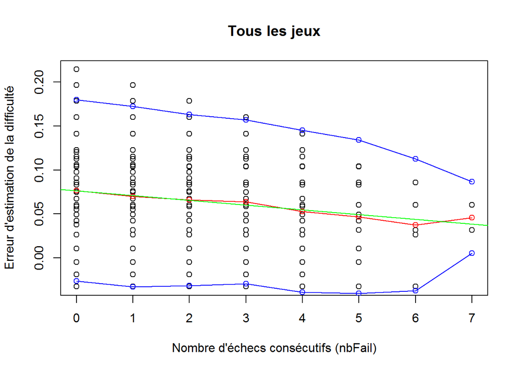

```
## [1] "Anova"
##               Df Sum Sq Mean Sq F value   Pr(>F)
## nbFail         1  0.171 0.17107    66.1 5.13e-16 ***
## Residuals   6298 16.300 0.00259
## ---
## Signif. codes:  0 '***' 0.001 '**' 0.01 '*' 0.05 '.' 0.1 ' ' 1
## [1] "Regression linéaire"
##
## Call:
## glm(formula = DTLoc$erreurDiffConfiance ~ DTLoc$nbFail)
##
## Deviance Residuals:
##       Min         1Q     Median         3Q        Max
## -0.109009  -0.028596   0.009228   0.036133   0.138002
##
## Coefficients:
##                Estimate Std. Error t value Pr(>|t|)
## (Intercept)   0.0763817  0.0007783   98.14  < 2e-16 ***
## DTLoc$nbFail -0.0054376  0.0006688   -8.13 5.13e-16 ***
## ---
## Signif. codes:  0 '***' 0.001 '**' 0.01 '*' 0.05 '.' 0.1 ' ' 1
##
## (Dispersion parameter for gaussian family taken to be 0.002588188)
##
##     Null deviance: 16.471  on 6299  degrees of freedom
## Residual deviance: 16.300  on 6298  degrees of freedom
## AIC: -19645
##
## Number of Fisher Scoring iterations: 2
```

```
## [1] "pvalue anova"
```

```
## [1] "5.1e-16 ***"
```

### Nombre de réussites consécutives

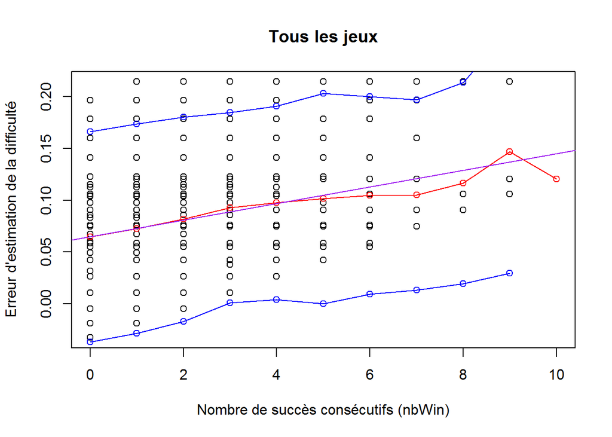

```
## [1] "Anova"
##               Df Sum Sq Mean Sq F value Pr(>F)
## nbWin          1  0.652  0.6517   259.5 <2e-16 ***
## Residuals   6298 15.820  0.0025
## ---
## Signif. codes:  0 '***' 0.001 '**' 0.01 '*' 0.05 '.' 0.1 ' ' 1
## [1] "Regression linéaire"
##
## Call:
## glm(formula = DTLoc$erreurDiffConfiance ~ DTLoc$nbWin)
##
## Deviance Residuals:
##      Min        1Q    Median        3Q       Max
## -0.09746  -0.03329   0.01033   0.03435   0.14152
##
## Coefficients:
##              Estimate Std. Error t value Pr(>|t|)
## (Intercept) 0.0648344  0.0008018   80.86   <2e-16 ***
## DTLoc$nbWin 0.0080298  0.0004985   16.11   <2e-16 ***
## ---
## Signif. codes:  0 '***' 0.001 '**' 0.01 '*' 0.05 '.' 0.1 ' ' 1
##
## (Dispersion parameter for gaussian family taken to be 0.002511872)
##
##     Null deviance: 16.471  on 6299  degrees of freedom
## Residual deviance: 15.820  on 6298  degrees of freedom
## AIC: -19834
##
## Number of Fisher Scoring iterations: 2
```

```
## [1] "pvalue anova"
```

```
## [1] "3.1e-57 ***"
```

### Indice de confiance lissé

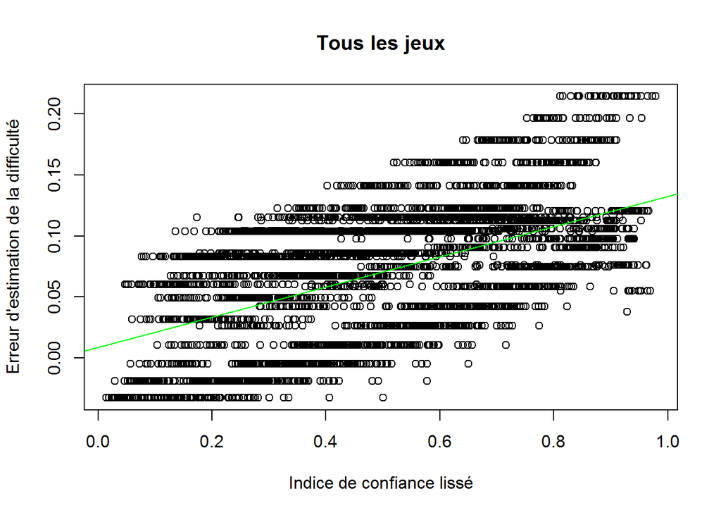

```
## [1] "Anova res lisse"
##               Df Sum Sq Mean Sq F value Pr(>F)
## resLisse       1  4.134   4.134    2110 <2e-16 ***
## Residuals   6298 12.338   0.002
## ---
## Signif. codes:  0 '***' 0.001 '**' 0.01 '*' 0.05 '.' 0.1 ' ' 1
## [1] "Regression linéaire"
##
## Call:
## glm(formula = DTLoc$erreurDiffConfiance ~ DTLoc$resLisse)
##
## Deviance Residuals:
##       Min         1Q     Median         3Q        Max
## -0.103125  -0.035898   0.008373   0.031506   0.105489
##
## Coefficients:
##                Estimate Std. Error t value Pr(>|t|)
## (Intercept)    0.008752   0.001502   5.829 5.86e-09 ***
## DTLoc$resLisse 0.123492   0.002688  45.936  < 2e-16 ***
## ---
## Signif. codes:  0 '***' 0.001 '**' 0.01 '*' 0.05 '.' 0.1 ' ' 1
##
## (Dispersion parameter for gaussian family taken to be 0.001959006)
##
##     Null deviance: 16.471  on 6299  degrees of freedom
## Residual deviance: 12.338  on 6298  degrees of freedom
## AIC: -21400
##
## Number of Fisher Scoring iterations: 2
```

```
## [1] "pvalue anova"
```

```
## [1] "0 ***"
```

## Difficulté logique

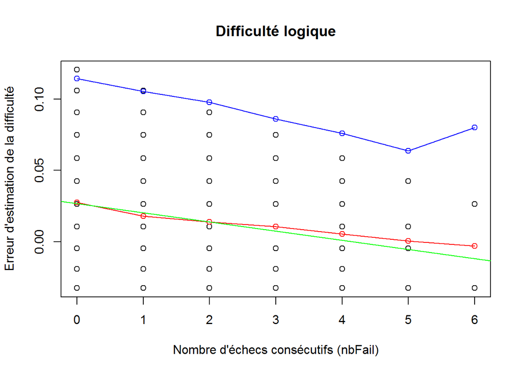

```
## [1] "Anova"
##               Df Sum Sq Mean Sq F value   Pr(>F)
## nbFail         1  0.076 0.07620   40.92 1.94e-10 ***
## Residuals   2158  4.019 0.00186
## ---
## Signif. codes:  0 '***' 0.001 '**' 0.01 '*' 0.05 '.' 0.1 ' ' 1
## [1] "Regression linéaire"
##
## Call:
## glm(formula = DTLoc$erreurDiffConfiance ~ DTLoc$nbFail)
##
## Deviance Residuals:
##       Min         1Q     Median         3Q        Max
## -0.059410  -0.039438  -0.009843   0.031837   0.093825
##
## Coefficients:
##               Estimate Std. Error t value Pr(>|t|)
## (Intercept)   0.026783   0.001112  24.094  < 2e-16 ***
## DTLoc$nbFail -0.006470   0.001011  -6.397 1.94e-10 ***
## ---
## Signif. codes:  0 '***' 0.001 '**' 0.01 '*' 0.05 '.' 0.1 ' ' 1
##
## (Dispersion parameter for gaussian family taken to be 0.001862487)
##
##     Null deviance: 4.0955  on 2159  degrees of freedom
## Residual deviance: 4.0192  on 2158  degrees of freedom
## AIC: -7443.6
##
## Number of Fisher Scoring iterations: 2
```

```
## [1] "pvalue anova"
```

```
## [1] "1.9e-10 ***"
```

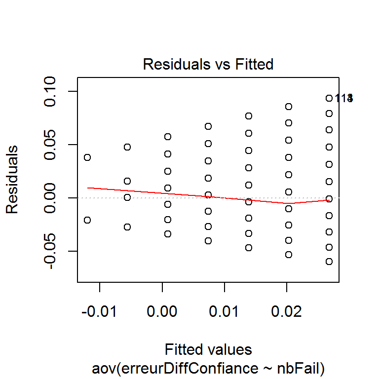

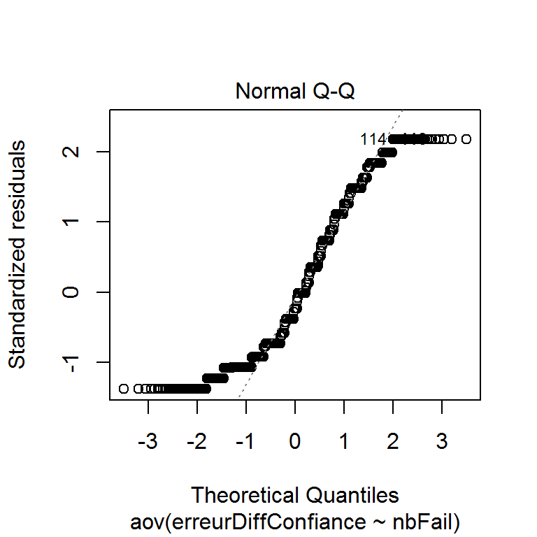

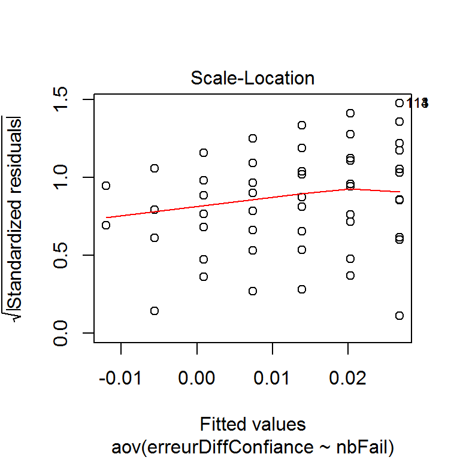

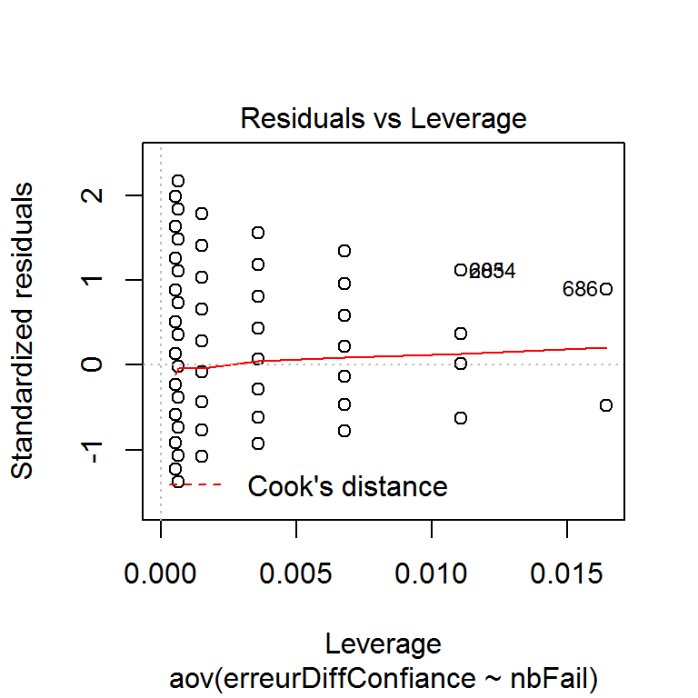

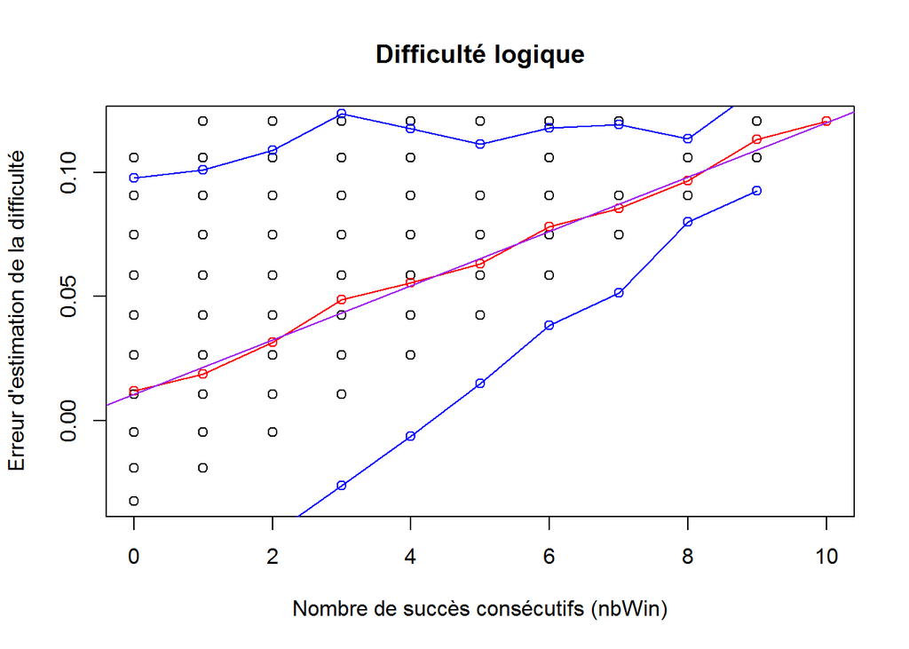

```
## [1] "Anova"
##               Df Sum Sq Mean Sq F value Pr(>F)
## nbWin          1  0.538  0.5382   326.5 <2e-16 ***
## Residuals   2158  3.557  0.0016
## ---
## Signif. codes:  0 '***' 0.001 '**' 0.01 '*' 0.05 '.' 0.1 ' ' 1
## [1] "Regression linéaire"
##
## Call:
## glm(formula = DTLoc$erreurDiffConfiance ~ DTLoc$nbWin)
##
## Deviance Residuals:
##      Min        1Q    Median        3Q       Max
## -0.04312  -0.03715  -0.01520   0.03185   0.09914
##
## Coefficients:
##              Estimate Std. Error t value Pr(>|t|)
## (Intercept) 0.0104977  0.0011101   9.457   <2e-16 ***
## DTLoc$nbWin 0.0109745  0.0006073  18.070   <2e-16 ***
## ---
## Signif. codes:  0 '***' 0.001 '**' 0.01 '*' 0.05 '.' 0.1 ' ' 1
##
## (Dispersion parameter for gaussian family taken to be 0.001648396)
##
##     Null deviance: 4.0955  on 2159  degrees of freedom
## Residual deviance: 3.5572  on 2158  degrees of freedom
## AIC: -7707.4
##
## Number of Fisher Scoring iterations: 2
```

```
## [1] "pvalue anova"
```

```
## [1] "4.5e-68 ***"
```

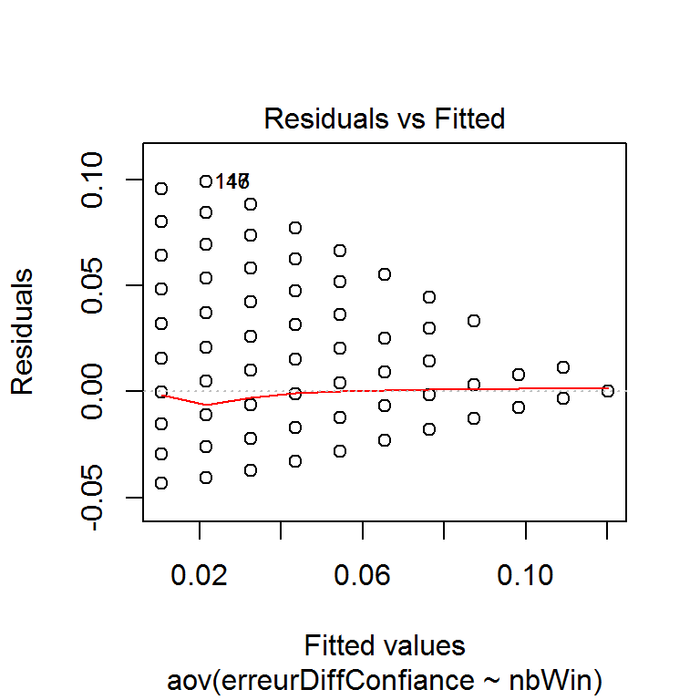

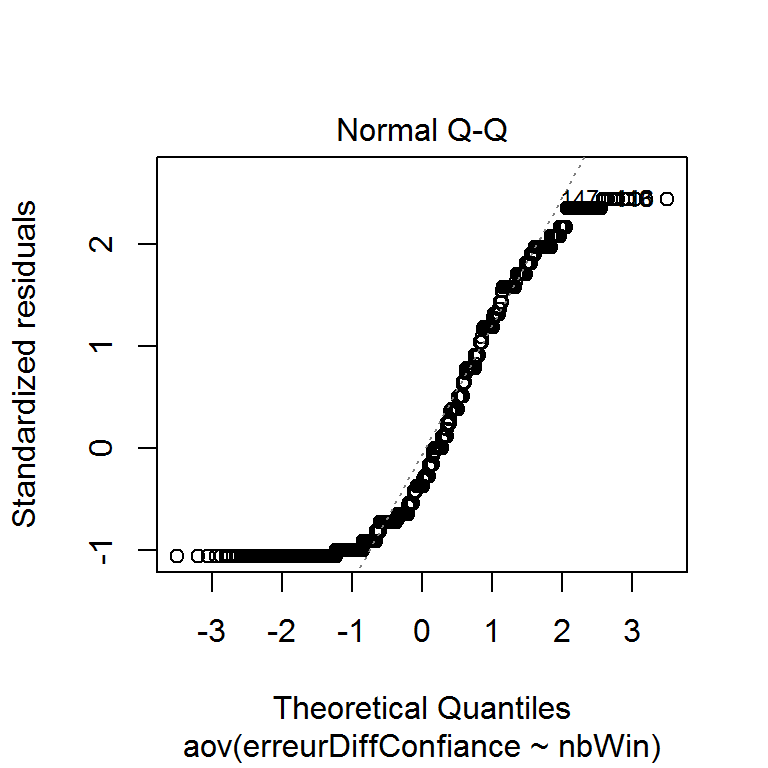

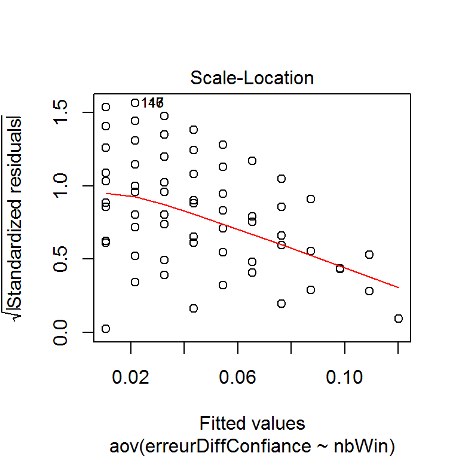

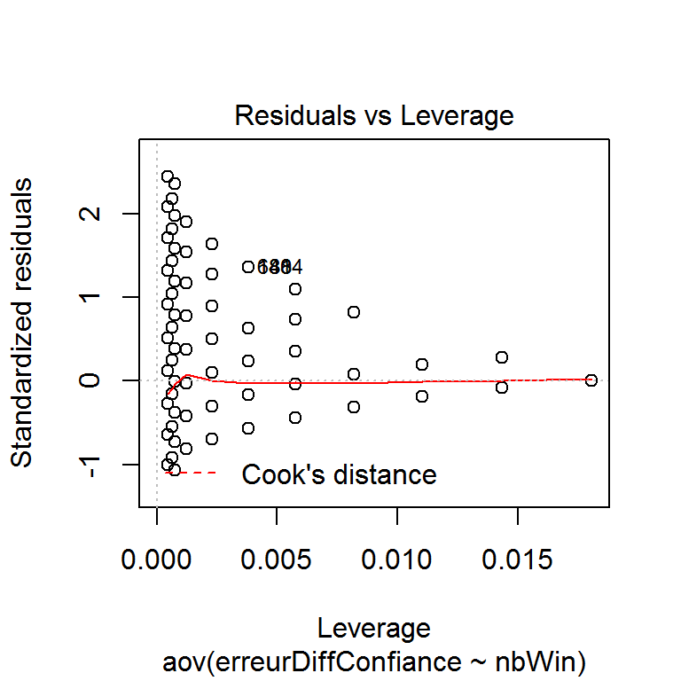

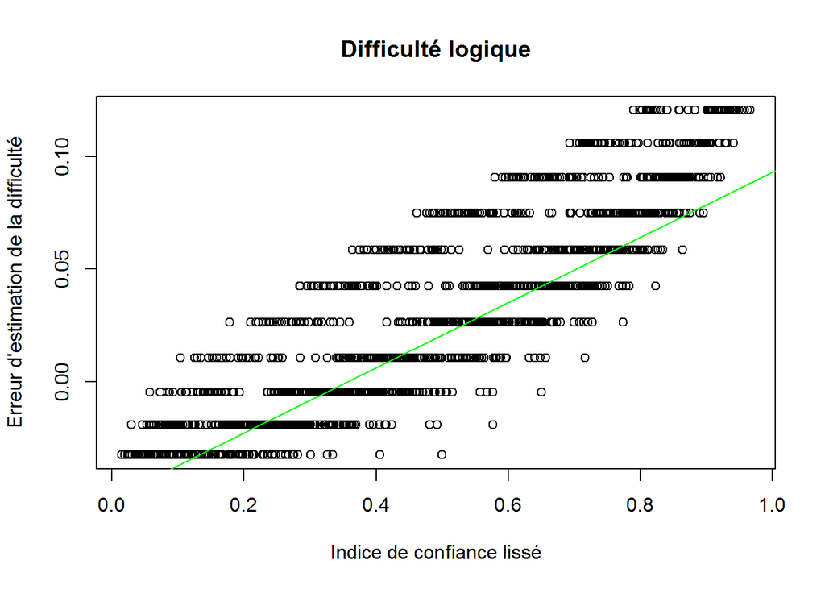

```
## [1] "Anova res lisse"
##               Df Sum Sq Mean Sq F value Pr(>F)
## resLisse       1  2.366  2.3658    2952 <2e-16 ***
## Residuals   2158  1.730  0.0008
## ---
## Signif. codes:  0 '***' 0.001 '**' 0.01 '*' 0.05 '.' 0.1 ' ' 1
## [1] "Regression linéaire"
##
## Call:
## glm(formula = DTLoc$erreurDiffConfiance ~ DTLoc$resLisse)
##
## Deviance Residuals:
##       Min         1Q     Median         3Q        Max
## -0.053335  -0.018282   0.000056   0.017642   0.059595
##
## Coefficients:
##                 Estimate Std. Error t value Pr(>|t|)
## (Intercept)    -0.051661   0.001501  -34.41   <2e-16 ***
## DTLoc$resLisse  0.144738   0.002664   54.33   <2e-16 ***
## ---
## Signif. codes:  0 '***' 0.001 '**' 0.01 '*' 0.05 '.' 0.1 ' ' 1
##
## (Dispersion parameter for gaussian family taken to be 0.0008015253)
##
##     Null deviance: 4.0955  on 2159  degrees of freedom
## Residual deviance: 1.7297  on 2158  degrees of freedom
## AIC: -9264.8
##
## Number of Fisher Scoring iterations: 2
```

```
## [1] "pvalue anova"
```

```
## [1] "0 ***"
```

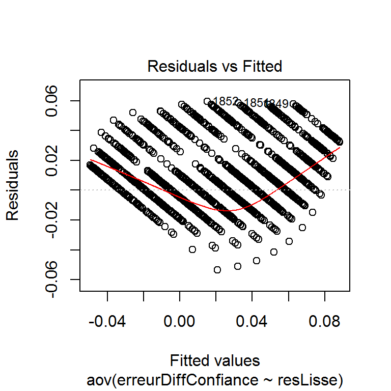

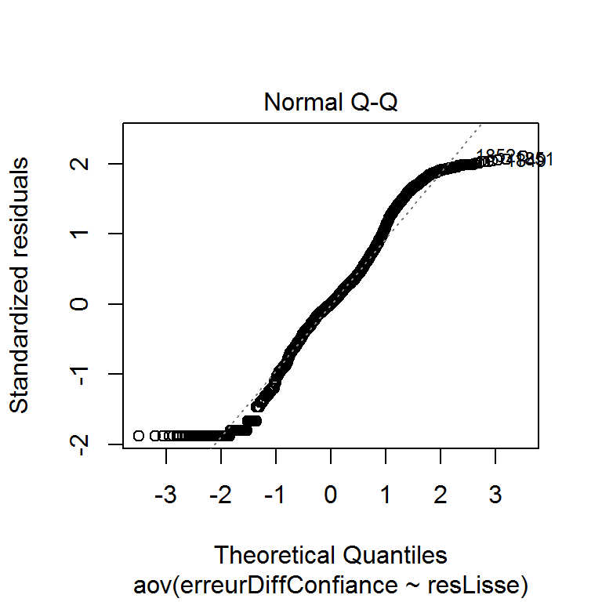

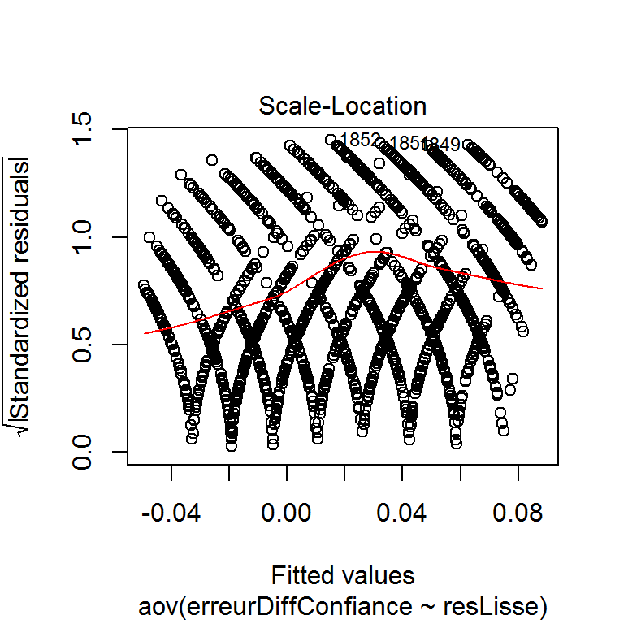

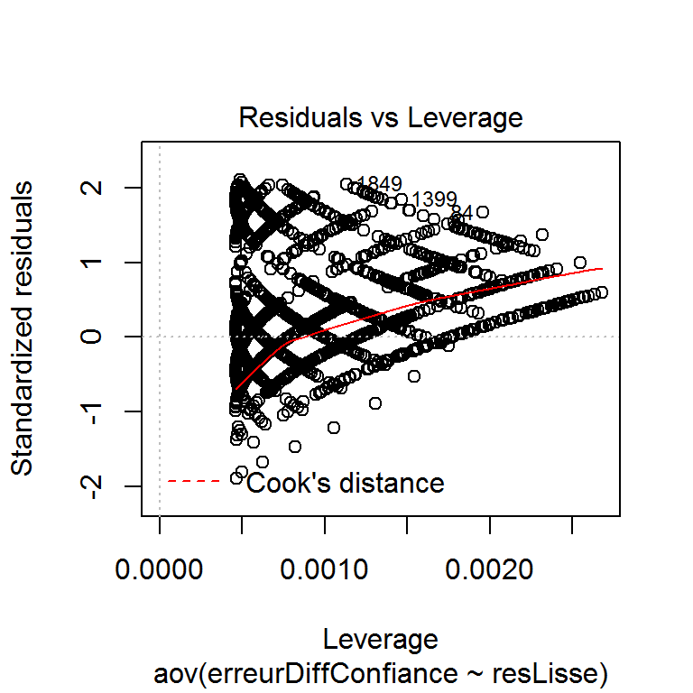

### Courbes de difficulte

```
## [1] "plotDiffCurves == FALSE"
```

## Difficulté motrice

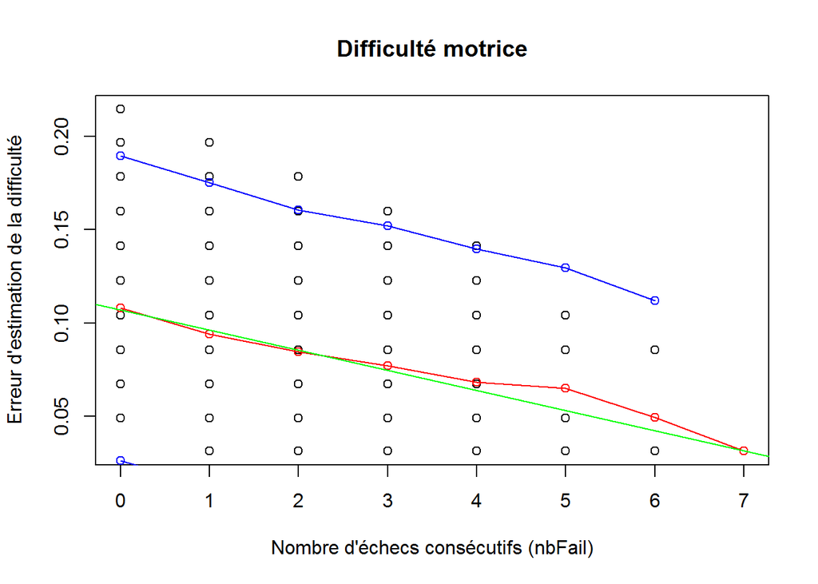

```
## [1] "Anova"
##               Df Sum Sq Mean Sq F value Pr(>F)
## nbFail         1  0.236 0.23567     146 <2e-16 ***
## Residuals   2038  3.289 0.00161
## ---
## Signif. codes:  0 '***' 0.001 '**' 0.01 '*' 0.05 '.' 0.1 ' ' 1
## [1] "Regression linéaire"
##
## Call:
## glm(formula = DTLoc$erreurDiffConfiance ~ DTLoc$nbFail)
##
## Deviance Residuals:
##       Min         1Q     Median         3Q        Max
## -0.064775  -0.029018  -0.002968   0.026386   0.107312
##
## Coefficients:
##               Estimate Std. Error t value Pr(>|t|)
## (Intercept)   0.107072   0.001089   98.32   <2e-16 ***
## DTLoc$nbFail -0.010755   0.000890  -12.08   <2e-16 ***
## ---
## Signif. codes:  0 '***' 0.001 '**' 0.01 '*' 0.05 '.' 0.1 ' ' 1
##
## (Dispersion parameter for gaussian family taken to be 0.001613987)
##
##     Null deviance: 3.5250  on 2039  degrees of freedom
## Residual deviance: 3.2893  on 2038  degrees of freedom
## AIC: -7322
##
## Number of Fisher Scoring iterations: 2
```

```
## [1] "pvalue anova"
```

```
## [1] "1.6e-32 ***"
```

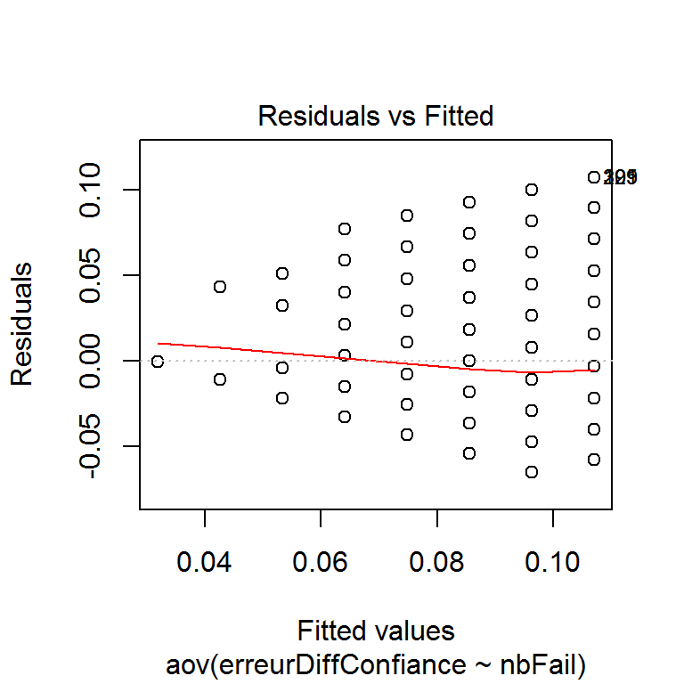

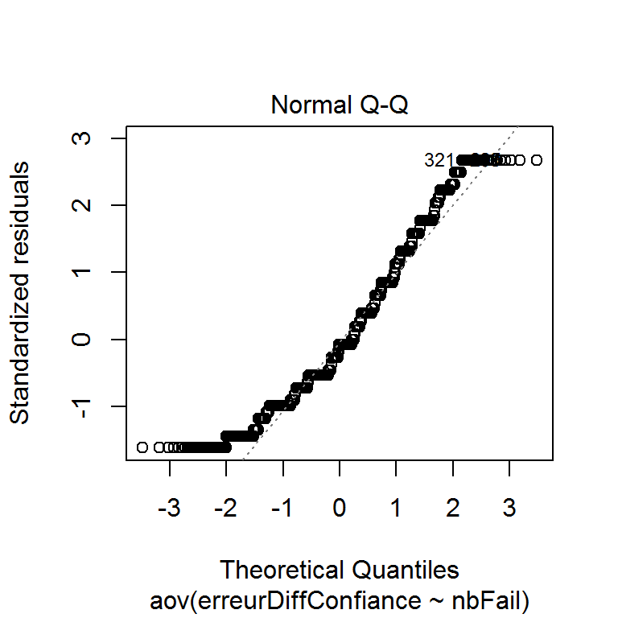

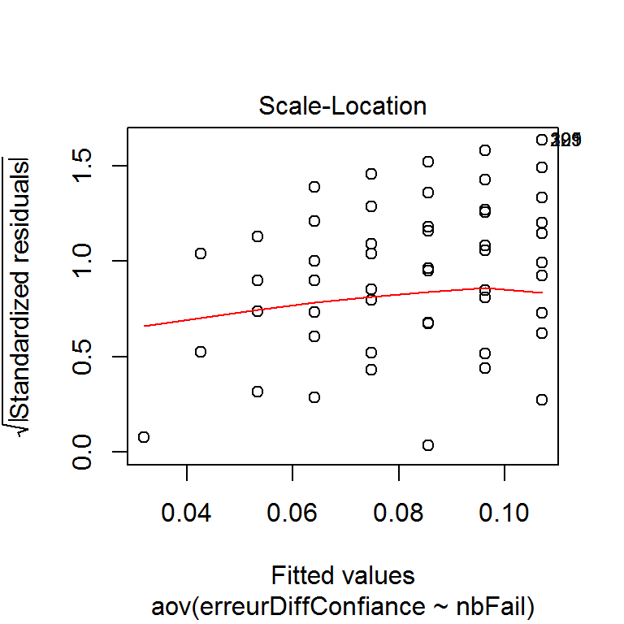

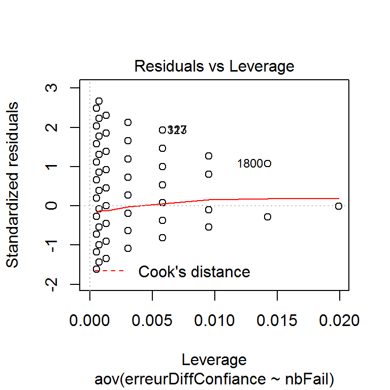

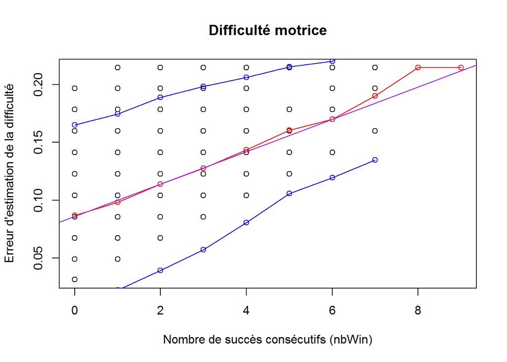

```
## [1] "Anova"
##               Df Sum Sq Mean Sq F value Pr(>F)
## nbWin          1 0.6083  0.6083     425 <2e-16 ***
## Residuals   2038 2.9167  0.0014
## ---
## Signif. codes:  0 '***' 0.001 '**' 0.01 '*' 0.05 '.' 0.1 ' ' 1
## [1] "Regression linéaire"
##
## Call:
## glm(formula = DTLoc$erreurDiffConfiance ~ DTLoc$nbWin)
##
## Deviance Residuals:
##      Min        1Q    Median        3Q       Max
## -0.05463  -0.01887  -0.01001   0.01793   0.11424
##
## Coefficients:
##              Estimate Std. Error t value Pr(>|t|)
## (Intercept) 0.0861739  0.0010574   81.49   <2e-16 ***
## DTLoc$nbWin 0.0139712  0.0006777   20.62   <2e-16 ***
## ---
## Signif. codes:  0 '***' 0.001 '**' 0.01 '*' 0.05 '.' 0.1 ' ' 1
##
## (Dispersion parameter for gaussian family taken to be 0.001431142)
##
##     Null deviance: 3.5250  on 2039  degrees of freedom
## Residual deviance: 2.9167  on 2038  degrees of freedom
## AIC: -7567.3
##
## Number of Fisher Scoring iterations: 2
```

```
## [1] "pvalue anova"
```

```
## [1] "6.3e-86 ***"
```

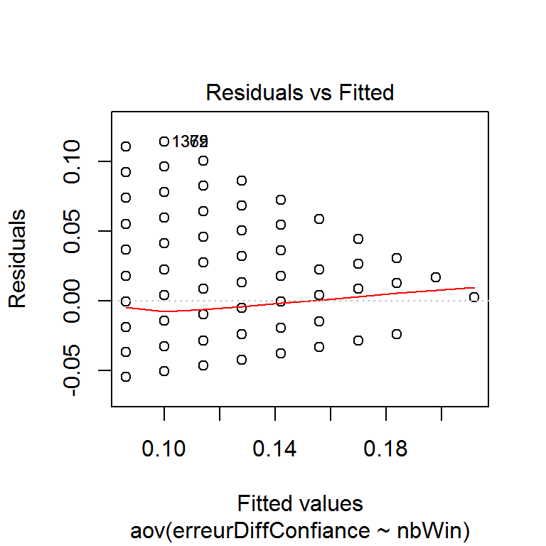

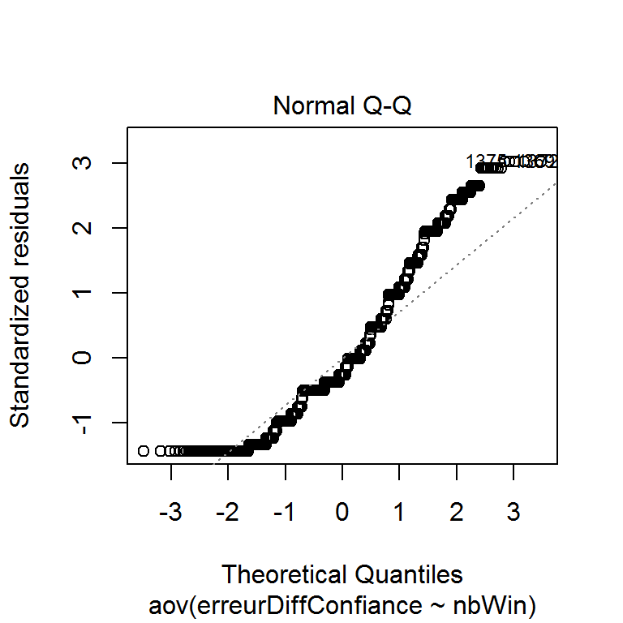

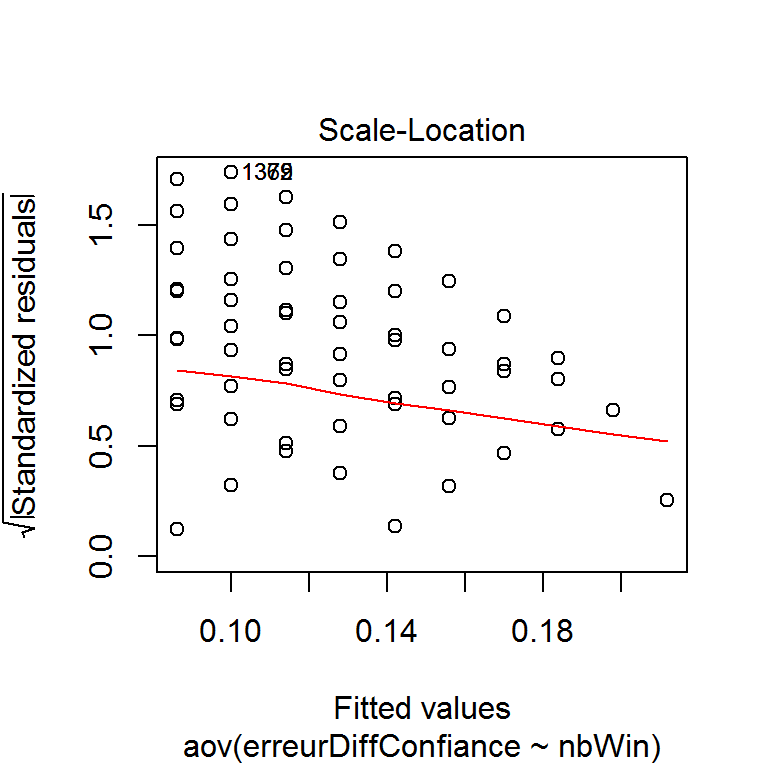

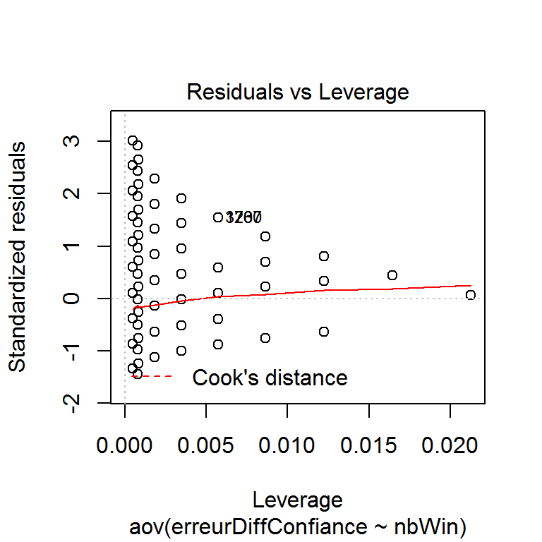